# 03 GARCH modeling

Author

Dybcio Katarzyna, Frejter Quoc

Published

May 8, 2024

```r
packages <- c("readr","xts","tidyverse", "DT", "patchwork", "ggthemes", "tseries", "stats", "forecast", "lmtest", "FinTS", "rugarch", "aTSA")

for (package in packages) {
  if (!require(package, character.only = TRUE)) {
    install.packages(package)
    library(package, character.only = TRUE)
  }
}
```

# 1 Load data

```r
SNEUCX_train <- read_rds("input/SNEUCX_train.rds")
source("functions/testdf.R")
```

# 2 Mean equation

## 2.1 ACF and PACF of log returns

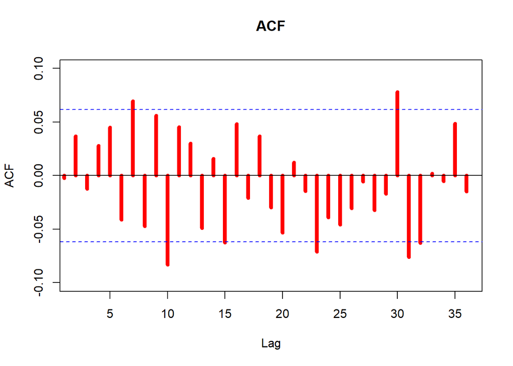

```r
par(mfrow = c(1, 1))
acf(SNEUCX_train$LnReturns,
    lag.max = 36,
    lwd = 5,
    col = "red",
    main = "ACF",
    xlim = c(2,36),
    ylim = c(-0.1,0.1))
```

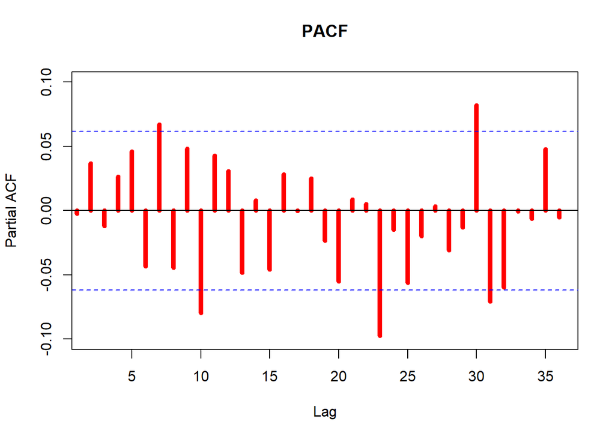

```r
pacf(SNEUCX_train$LnReturns,
     lag.max = 36,
     lwd = 5,
     col = "red",
     main = "PACF",
     xlim = c(2,36),
     ylim = c(-0.1,0.1))
```

```r
par(mfrow = c(1, 1))
```

ACF and PACF plots show that 7th and 10th lags are significant. This suggest analizing model ARMA up to order 10 of p and q.

## 2.2 Mean equation model

We will choose models based on BIC criterion as it penalizes large number of parameters the most. We prefer parsimonious models that won’t over fit. We fit models with p up to 10 and q up to 10. Some models will be defined manually as auto.arima doesn’t take into consideration models, that have only for example 10th lag without lags from 1 to 9.

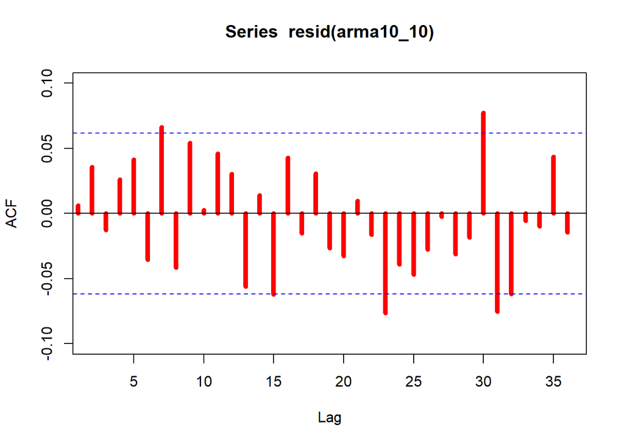

```r
Akaike <-c()
Bayes <-c()

arma10_10 <- Arima(SNEUCX_train$LnReturns,
                  order = c(10, 0, 10),
                  fixed = c(0,0,0,0,0,0,0,0,0,NA,0,0,0,0,0,0,0,0,0,NA,NA)
                  )
Akaike <- rbind(Akaike,AIC(arma10_10))
Bayes <- rbind(Bayes,BIC(arma10_10))

arma7_10_7_10 <- Arima(SNEUCX_train$LnReturns,
                  order = c(10, 0, 10),
                  fixed = c(0,0,0,0,0,0,NA,0,0,NA,0,0,0,0,0,0,NA,0,0,NA,NA)
                  )
Akaike <- rbind(Akaike,AIC(arma7_10_7_10))
Bayes <- rbind(Bayes,BIC(arma7_10_7_10))

arma0_7 <- Arima(SNEUCX_train$LnReturns,
                  order = c(0, 0, 7),
                 fixed = c(0,0,0,0,0,0,NA,NA)
                  )
Akaike <- rbind(Akaike,AIC(arma0_7))
Bayes <- rbind(Bayes,BIC(arma0_7))

arma7_0 <- Arima(SNEUCX_train$LnReturns,
                  order = c(7, 0, 0),
                 fixed = c(0,0,0,0,0,0,NA,NA)
                  )
Akaike <- rbind(Akaike,AIC(arma7_0))
Bayes <- rbind(Bayes,BIC(arma7_0))

arma1_0 <- Arima(SNEUCX_train$LnReturns,
                  order = c(1, 0, 0)
                  )
Akaike <- rbind(Akaike,AIC(arma1_0))
Bayes <- rbind(Bayes,BIC(arma1_0))

arma0_1 <- Arima(SNEUCX_train$LnReturns,
                  order = c(0, 0, 1)
                  )
Akaike <- rbind(Akaike,AIC(arma1_0))
Bayes <- rbind(Bayes,BIC(arma1_0))

arma0_0 <- Arima(SNEUCX_train$LnReturns,
                  order = c(0, 0, 0)
                  )

Akaike <- rbind(Akaike,AIC(arma0_0))
Bayes <- rbind(Bayes,BIC(arma0_0))

acf(resid(arma10_10),
    lag.max = 36,
    lwd = 5,
    col = "red",
    xlim = c(2,36),
    ylim = c(-0.1,0.1))
```

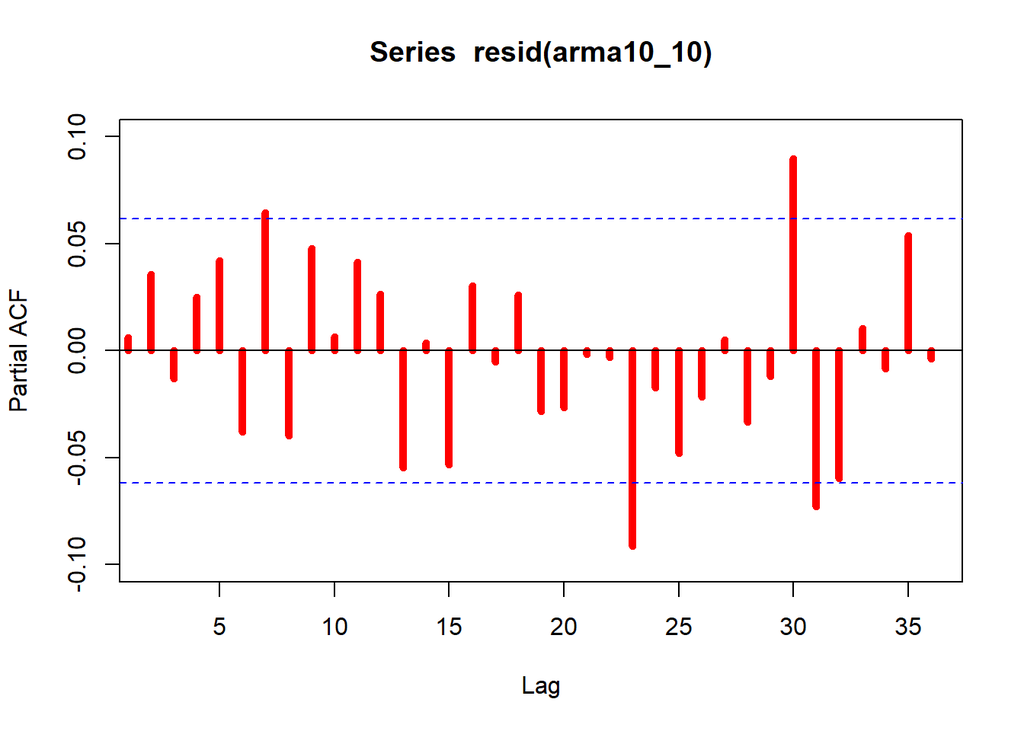

```r
pacf(resid(arma10_10),
     lag.max = 36,
     lwd = 5,
     col = "red",
     xlim = c(2,36),
     ylim = c(-0.1,0.1))
```

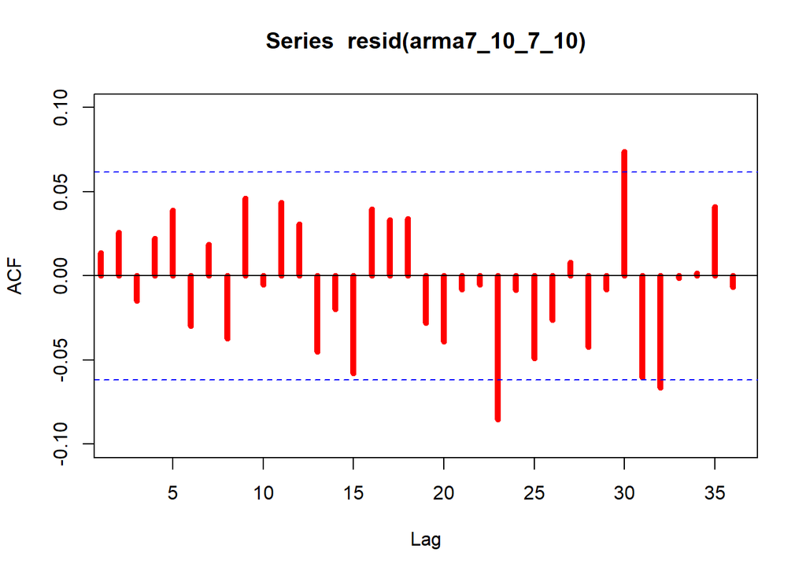

```r
acf(resid(arma7_10_7_10),
    lag.max = 36,
    lwd = 5,
    col = "red",
    xlim = c(2,36),
    ylim = c(-0.1,0.1))
```

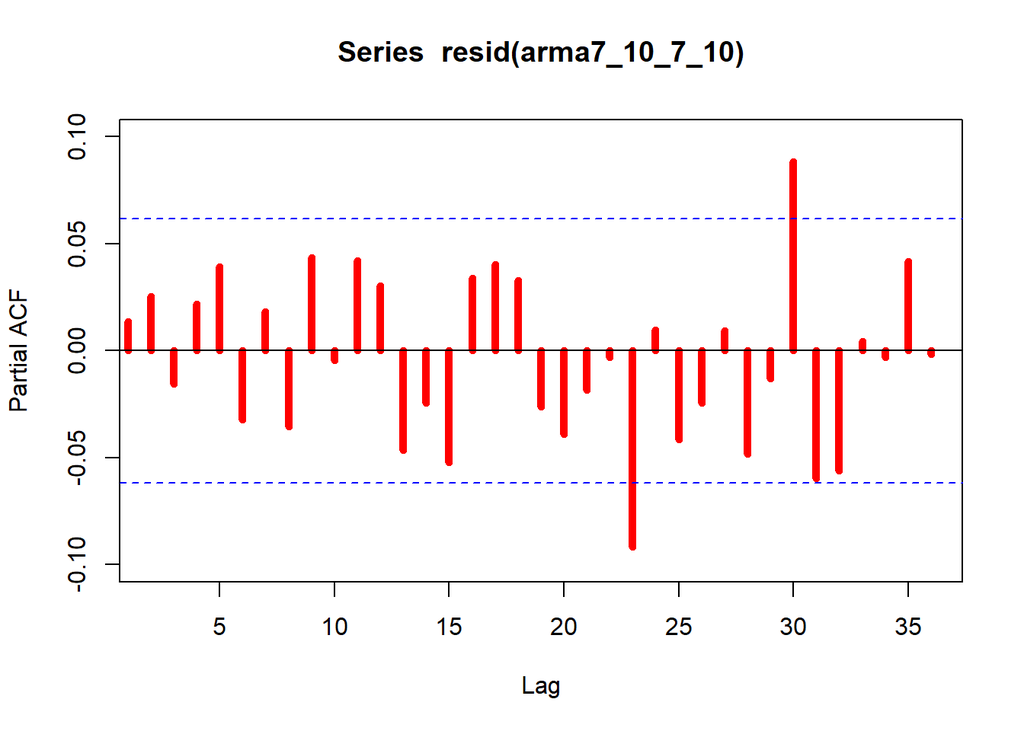

```r
pacf(resid(arma7_10_7_10),
     lag.max = 36,
     lwd = 5,
     col = "red",
     xlim = c(2,36),
     ylim = c(-0.1,0.1))
```

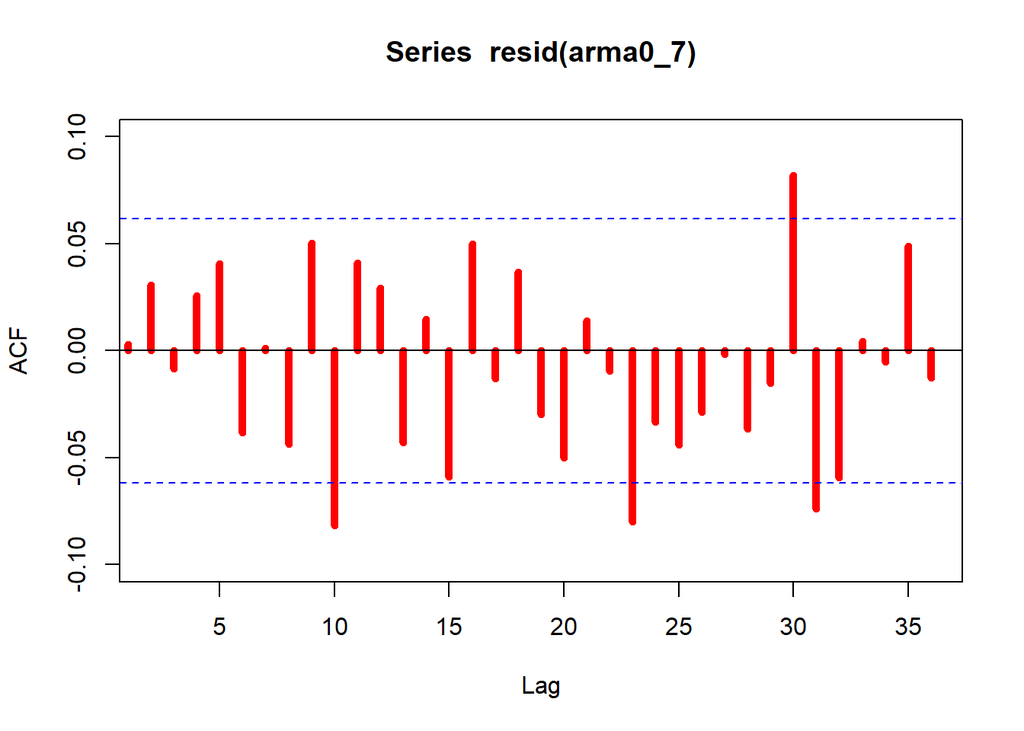

```r
acf(resid(arma0_7),
    lag.max = 36,
    lwd = 5,
    col = "red",
    xlim = c(2,36),
    ylim = c(-0.1,0.1))
```

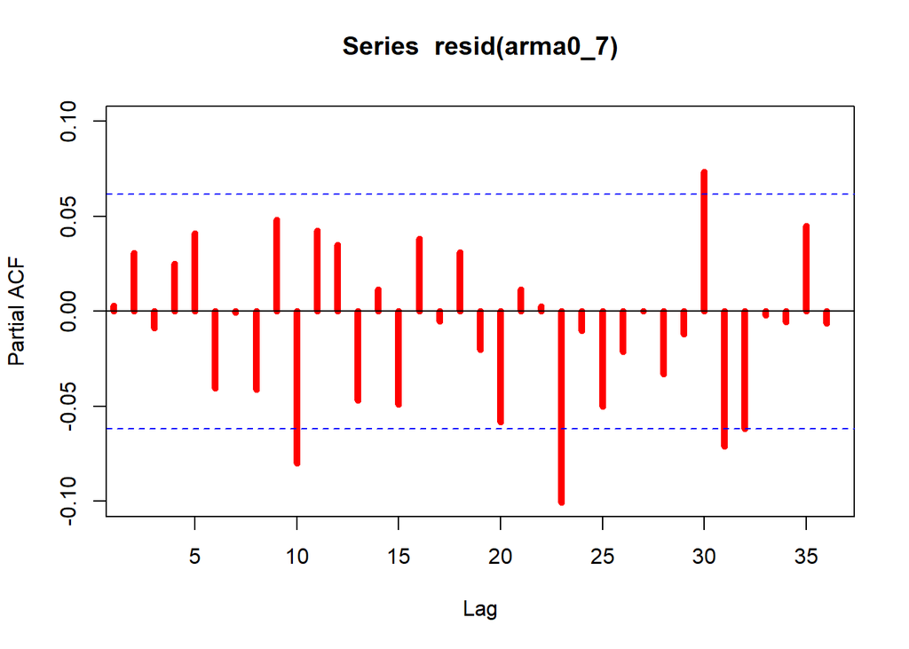

```r
pacf(resid(arma0_7),
     lag.max = 36,
     lwd = 5,
     col = "red",
     xlim = c(2,36),
     ylim = c(-0.1,0.1))
```

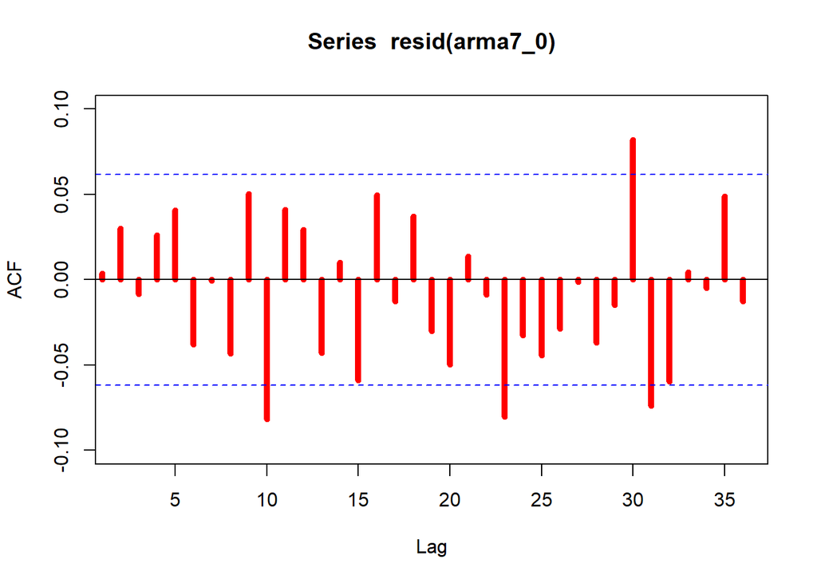

```r
acf(resid(arma7_0),
    lag.max = 36,
    lwd = 5,
    col = "red",
    xlim = c(2,36),
    ylim = c(-0.1,0.1))
```

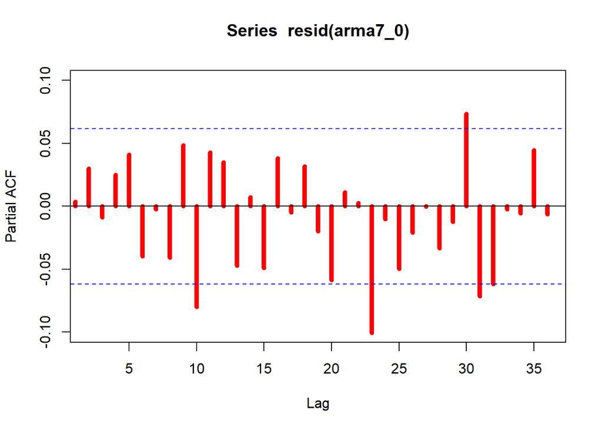

```r
pacf(resid(arma7_0),
     lag.max = 36,
     lwd = 5,
     col = "red",
     xlim = c(2,36),
     ylim = c(-0.1,0.1))
```

```r
arima.best.BIC <-
  auto.arima(SNEUCX_train$LnReturns,
             max.p = 10,
             max.q = 10,
             max.order = 20,
             ic = 'bic',
             stepwise = FALSE)
print(arima.best.BIC)
```

```
Series: SNEUCX_train$LnReturns
ARIMA(0,0,0) with zero mean

sigma^2 = 0.0003605:  log likelihood = 2562.82
AIC=-5123.64   AICc=-5123.64   BIC=-5118.73
```

ACF and PACF plots shows us that adding 10th lag to ma and ar equation removes statistically significant 10th lag and 7th lag remains borderline significant. ARMA with only 7th lag in AR or 7th lag in MA still shows 10th significant lag in PACF or ACF.

Auto arima function proposes ARMA00 or so called naive model.

```r
model_name <- c("arma10_10","arma7_10_7_10","arma0_7","arma7_0", "arma1_0","arma0_1","arma0_0")

scores <- cbind(model_name, Akaike, Bayes)
colnames(scores) <- c("Model","Akaike","Bayes")

scores %>%
  datatable(rownames = FALSE, class = 'cell-border stripe') %>%
  formatRound(columns = c("Akaike","Bayes"), digits = 0)
```

| Model | Akaike | Bayes |
| --- | --- | --- |
| arma10_10 | -5127.74106295591 | -5108.08213938504 |
| arma7_10_7_10 | -5129.37370289574 | -5099.88531753943 |
| arma0_7 | -5126.15918540053 | -5111.41499272238 |
| arma7_0 | -5126.27754019763 | -5111.53334751947 |
| arma1_0 | -5121.41077936713 | -5106.66658668897 |
| arma0_1 | -5121.41077936713 | -5106.66658668897 |
| arma0_0 | -5123.40479177913 | -5113.57532999369 |

Manually created models compared to “no model” perform worse in terms of BIC score. In that case we will continue with ARIMA(0,0,0)

## 2.3 Stationarity testing

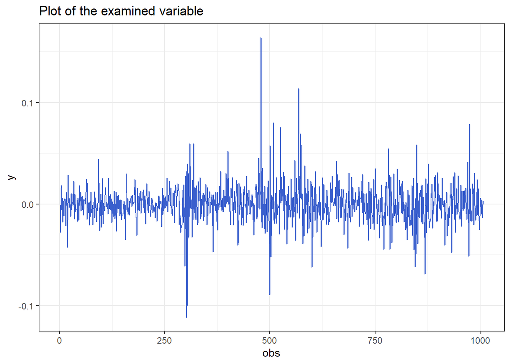

| augmentations | adf | p_adf | bgodfrey | p_bg |
| --- | --- | --- | --- | --- |
| 0 | -31.76300851654241 | 0.01 | 8.493101473303881e-07 | 0.9992646854553373 |
| 1 | -21.62457790235918 | 0.01 | 0.002687425002559692 | 0.9586558801733557 |
| 2 | -18.03845123371186 | 0.01 | 0.0002602168115195221 | 0.9871296931237797 |
| 3 | -15.23754994215232 | 0.01 | 0.0007899148198992053 | 0.9775780686010278 |

```r
testdf(variable = arma0_0$residuals,
       max.augmentations = 3) %>%
  datatable(rownames = FALSE, options = list(dom = 't', ordering=F), class = 'cell-border stripe') %>%
  formatRound(columns = c('adf', 'p_adf', 'bgodfrey', 'p_bg'), digits = 4)
```

Based on Breusch Godfrey test we can not reject hypothesis that there is no autocorrelation among residuals for DF test with 0 augmentations. P-value for ADF test with zero augmentations is low - we can reject hypothesis that time series is non stationary. Residuals of ARIMA(0,0) is stationary.

# 3 ARCH effect

## 3.1 Serial autocorrelation

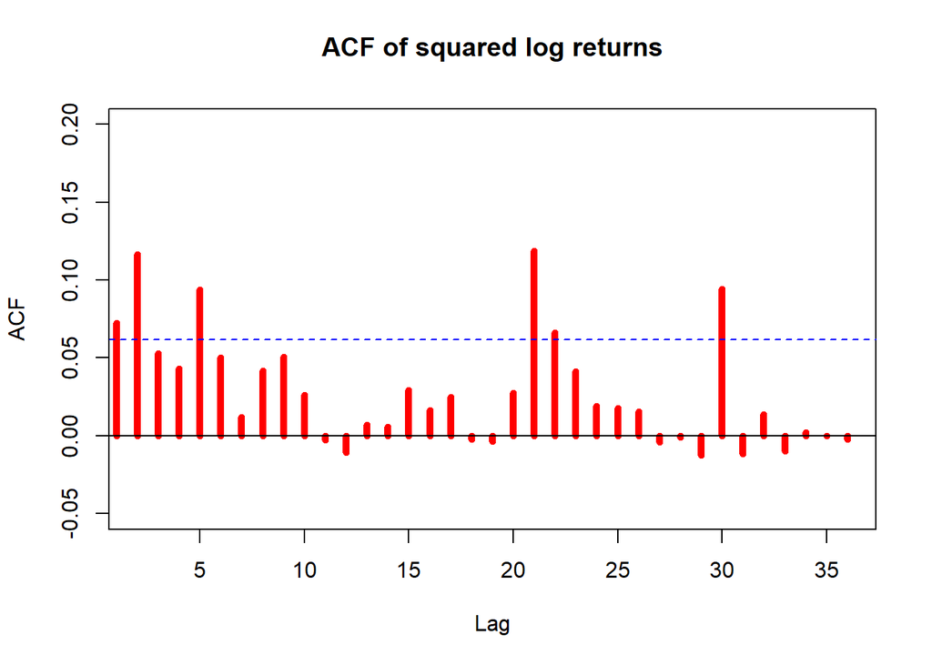

```r
acf(SNEUCX_train$LnReturns^2,
    lag.max = 36,
    lwd = 5,
    col = "red",
    main = "ACF of squared log returns",
    xlim = c(2,36),
    ylim = c(-0.05,0.2))
```

Based on ACF on squared log returns/residuals of ARMA(0,0) we can see that serial autocorrelation is present which suggest ARCH effects.

## 3.2 ARCH test

```
ARCH heteroscedasticity test for residuals
alternative: heteroscedastic

Portmanteau-Q test:
     order   PQ    p.value
[1,]     4 24.9 0.00005263
[2,]     8 37.7 0.00000847
[3,]    12 41.2 0.00004607
[4,]    16 42.4 0.00034031
[5,]    20 43.9 0.00153346
[6,]    24 65.2 0.00001123
Lagrange-Multiplier test:
     order   LM p.value
[1,]     4 2142       0
[2,]     8  981       0
[3,]    12  630       0
[4,]    16  464       0
[5,]    20  367       0
[6,]    24  259       0
```

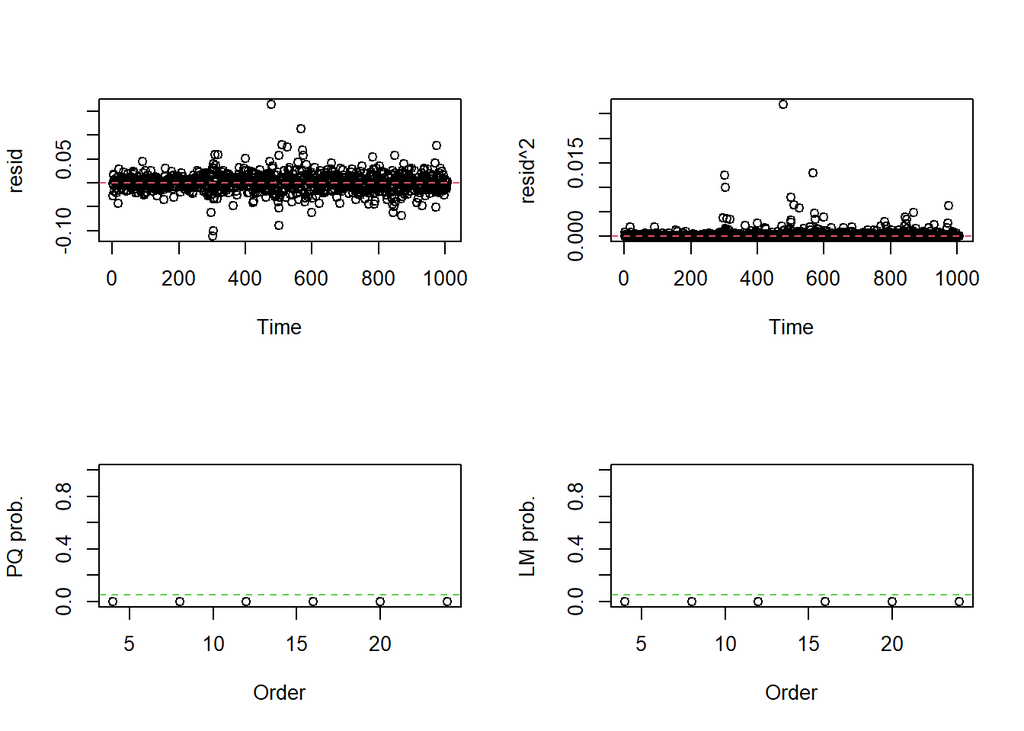

```r
arma0_0 <- arima(SNEUCX_train$LnReturns,order = c(0,0,0))
arch.test(arma0_0)
```

Formally testing time series with ARCH LM test we can reject null hypothesis that ARCH effect is not present. In Portmanteau-Q test and Lagrange-Multiplier test we are rejecting null hypothesis indicating there is autocorrelation in squared residuals.

# 4 ARCH models

## 4.1 ARCH(1)

```r
spec <- ugarchspec(variance.model = list(garchOrder = c(1,0)), mean.model = list(armaOrder = c(0, 0)))
ARCH1 <- ugarchfit(spec = spec, data = SNEUCX_train$LnReturns, solver = "hybrid")
print(ARCH1)
```

```
*---------------------------------*
*          GARCH Model Fit        *
*---------------------------------*

Conditional Variance Dynamics
-----------------------------------
GARCH Model : sGARCH(1,0)
Mean Model  : ARFIMA(0,0,0)
Distribution    : norm

Optimal Parameters
------------------------------------
        Estimate  Std. Error  t value Pr(>|t|)
mu      0.000640    0.000582   1.1001 0.271283
omega   0.000307    0.000018  17.3315 0.000000
alpha1  0.167276    0.052661   3.1765 0.001491

Robust Standard Errors:
        Estimate  Std. Error  t value Pr(>|t|)
mu      0.000640    0.000604   1.0606  0.28889
omega   0.000307    0.000049   6.2242  0.00000
alpha1  0.167276    0.114725   1.4581  0.14483

LogLikelihood : 2577.739

Information Criteria
------------------------------------

Akaike       -5.1137
Bayes        -5.0990
Shibata      -5.1137
Hannan-Quinn -5.1081

Weighted Ljung-Box Test on Standardized Residuals
------------------------------------
                        statistic p-value
Lag[1]                     0.6306  0.4271
Lag[2*(p+q)+(p+q)-1][2]    1.0119  0.4944
Lag[4*(p+q)+(p+q)-1][5]    1.9297  0.6351
d.o.f=0
```

[output cut: 33 more lines]

```
Negative Sign Bias  0.6554 0.5123
Positive Sign Bias  0.5021 0.6157
Joint Effect        1.2378 0.7440


Adjusted Pearson Goodness-of-Fit Test:
------------------------------------
  group statistic   p-value(g-1)
1    20     80.21 0.000000001711
2    30     87.93 0.000000075674
3    40    106.21 0.000000038827
4    50    105.76 0.000004744248


Elapsed time : 0.1922271
```

```r
jarque.bera.test(ARCH1@fit$residuals/sqrt(sigma(ARCH1)))
```

```
    Jarque Bera Test

data:  ARCH1@fit$residuals/sqrt(sigma(ARCH1))
X-squared = 4457.1, df = 2, p-value < 2.2e-16
```

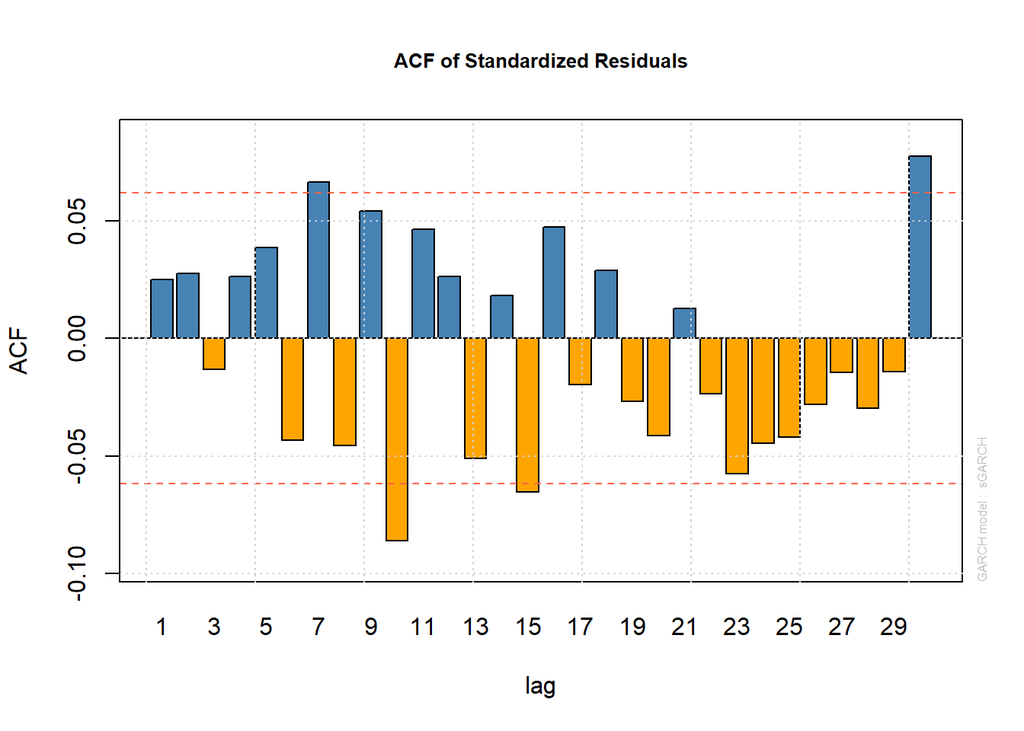

```r
plot(ARCH1,which = 10)
```

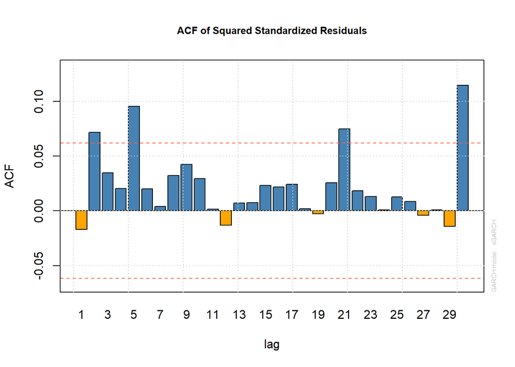

```r
plot(ARCH1,which = 11)
```

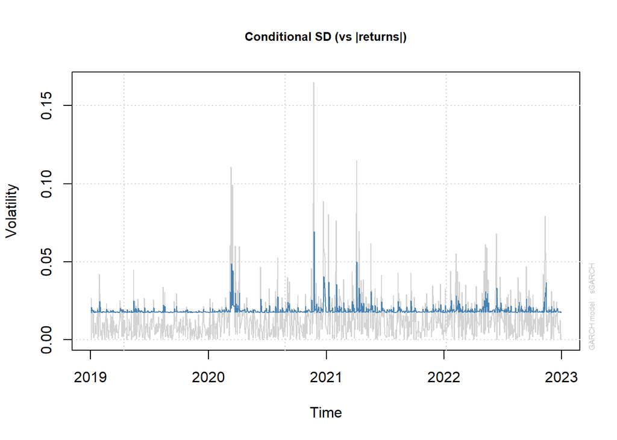

```r
plot(ARCH1,which = 3)
```

In optimal parameter section we can see that all parameters are statistically significant except for mu - mean parameter, alpha1 becomes less significant if we take into consideration robust standard errors.

Weighted Ljung-Box test on Standardized Residuals tells us that mean equation seems to be correct as we don’t have any significant autocorrelations.

Based on Weighted Ljung-Box Test on Standardized Squared Residuals, we can notice that fifth lag is still significant suggesting that variance equation may be enhanced.

We cannot reject the hypothesis that ARCH effects is not present based on 2, 4 and 6th lag.

Nyblom stability test suggest that jointly model is not stable - statistic is greater than 10% critical value, if we look at this individually omega is likely to change in time.

Additionally we reject the hypothesis that leverage effect exists.

ACF plot of standardized residuals shows significant autocorrelation for 7th and 10th lag.

ACF plot of squared standardized residuals shows significant autocorrelation for 5th lag. We will add up to 5th lag of innovation to next model.

Based on Adjusted Pearson Goodness-of-Fit Test we can see that normal distribution does not fit the data.

Standardized residuals don’t have normal distribution.

## 4.2 ARCH(5)

```r
spec <- ugarchspec(variance.model = list(garchOrder = c(5,0)), mean.model = list(armaOrder = c(0, 0)))
ARCH5 <- ugarchfit(spec = spec, data = SNEUCX_train$LnReturns, solver = "hybrid")
print(ARCH5)
```

```
*---------------------------------*
*          GARCH Model Fit        *
*---------------------------------*

Conditional Variance Dynamics
-----------------------------------
GARCH Model : sGARCH(5,0)
Mean Model  : ARFIMA(0,0,0)
Distribution    : norm

Optimal Parameters
------------------------------------
        Estimate  Std. Error  t value Pr(>|t|)
mu      0.000397    0.000505  0.78623 0.431735
omega   0.000168    0.000016 10.42881 0.000000
alpha1  0.079591    0.033213  2.39638 0.016558
alpha2  0.138109    0.047389  2.91434 0.003564
alpha3  0.097554    0.036852  2.64717 0.008117
alpha4  0.006997    0.015060  0.46460 0.642214
alpha5  0.281294    0.056939  4.94023 0.000001

Robust Standard Errors:
        Estimate  Std. Error  t value Pr(>|t|)
mu      0.000397    0.000539  0.73667 0.461321
omega   0.000168    0.000029  5.77651 0.000000
alpha1  0.079591    0.060658  1.31214 0.189474
alpha2  0.138109    0.062427  2.21231 0.026946
alpha3  0.097554    0.069225  1.40924 0.158764
alpha4  0.006997    0.011957  0.58520 0.558411
alpha5  0.281294    0.161746  1.73911 0.082016

LogLikelihood : 2632.343

Information Criteria
------------------------------------

Akaike       -5.2142
Bayes        -5.1800
Shibata      -5.2143
Hannan-Quinn -5.2012
```

[output cut: 45 more lines]

```
Negative Sign Bias  1.1246 0.2610
Positive Sign Bias  0.9586 0.3380
Joint Effect        2.1841 0.5351


Adjusted Pearson Goodness-of-Fit Test:
------------------------------------
  group statistic p-value(g-1)
1    20     65.00 0.0000006115
2    30     67.91 0.0000583293
3    40     91.11 0.0000046978
4    50     89.38 0.0003772148


Elapsed time : 0.2418411
```

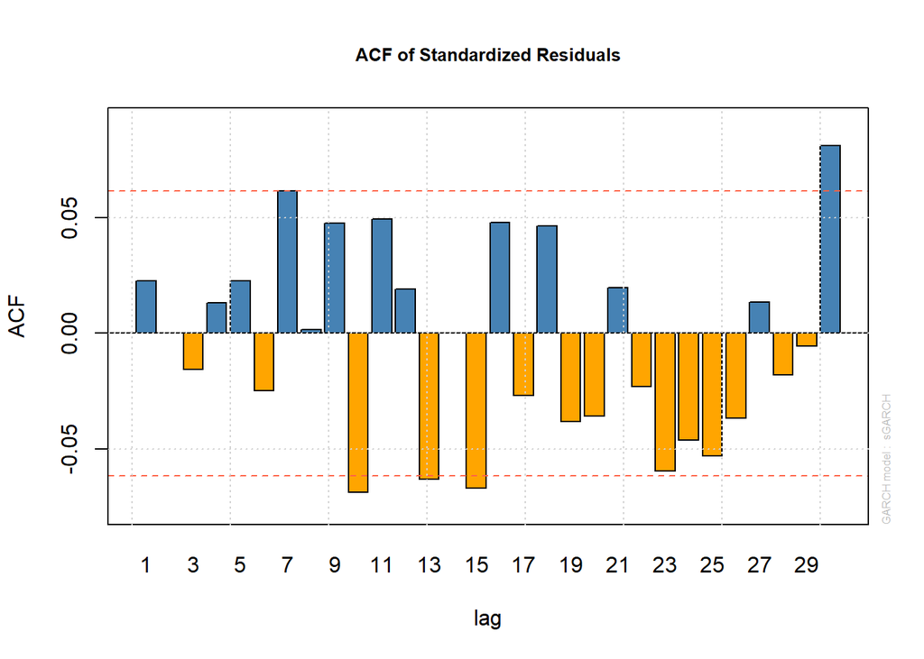

```r
plot(ARCH5,which = 10)
```

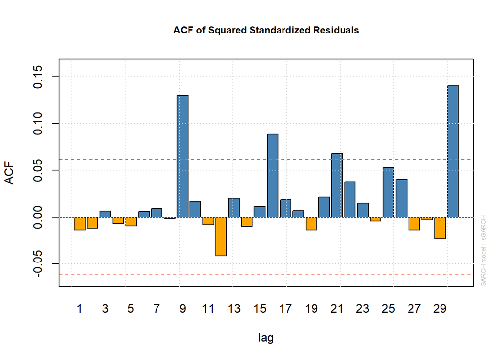

```r
plot(ARCH5,which = 11)
```

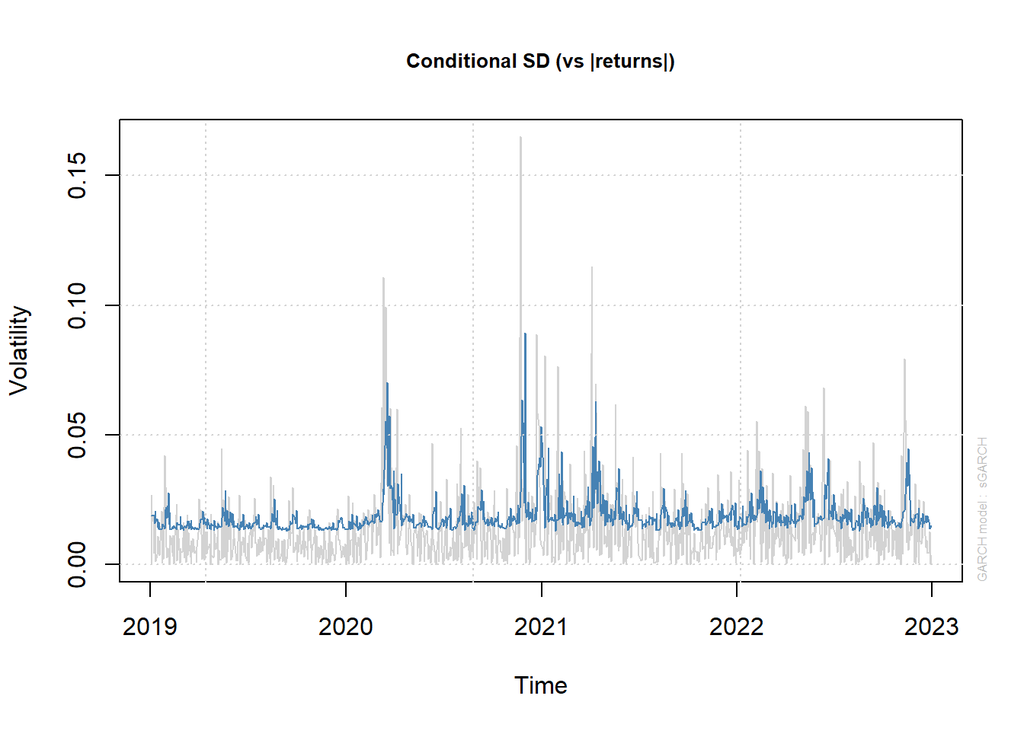

```r
plot(ARCH5,which = 3)
```

Now based on Weighted Ljung-Box Test on Standardized Squared Residuals auto-correlation is no longer present. Analyzing ACF plot for squared standardized residuals 9th lag became autocorrelated.

ARCH effect is present for 10th lag. We will proceed with ARCH9

## 4.3 ARCH(9)

```r
spec <- ugarchspec(variance.model = list(garchOrder = c(9,0)), mean.model = list(armaOrder = c(0, 0)))
ARCH9 <- ugarchfit(spec = spec, data = SNEUCX_train$LnReturns, solver = "hybrid")
print(ARCH9)
```

```
*---------------------------------*
*          GARCH Model Fit        *
*---------------------------------*

Conditional Variance Dynamics
-----------------------------------
GARCH Model : sGARCH(9,0)
Mean Model  : ARFIMA(0,0,0)
Distribution    : norm

Optimal Parameters
------------------------------------
        Estimate  Std. Error  t value Pr(>|t|)
mu      0.000374    0.000495 0.754945 0.450282
omega   0.000122    0.000016 7.391145 0.000000
alpha1  0.078537    0.032998 2.380086 0.017309
alpha2  0.152463    0.049158 3.101472 0.001926
alpha3  0.087833    0.034269 2.563016 0.010377
alpha4  0.001538    0.016353 0.094025 0.925089
alpha5  0.246245    0.051507 4.780796 0.000002
alpha6  0.032192    0.032423 0.992867 0.320775
alpha7  0.039718    0.039019 1.017893 0.308729
alpha8  0.001760    0.012674 0.138902 0.889527
alpha9  0.106666    0.041710 2.557348 0.010547

Robust Standard Errors:
        Estimate  Std. Error  t value Pr(>|t|)
mu      0.000374    0.000545  0.68647 0.492418
omega   0.000122    0.000023  5.39079 0.000000
alpha1  0.078537    0.063170  1.24326 0.213771
alpha2  0.152463    0.060438  2.52263 0.011648
alpha3  0.087833    0.064524  1.36124 0.173438
alpha4  0.001538    0.014586  0.10542 0.916045
alpha5  0.246245    0.152968  1.60978 0.107446
alpha6  0.032192    0.033911  0.94933 0.342455
alpha7  0.039718    0.050079  0.79309 0.427723
alpha8  0.001760    0.008329  0.21136 0.832606
alpha9  0.106666    0.070862  1.50527 0.132254

LogLikelihood : 2649.936
```

[output cut: 57 more lines]

```
Negative Sign Bias  1.2086 0.2271
Positive Sign Bias  1.1962 0.2319
Joint Effect        3.0013 0.3914


Adjusted Pearson Goodness-of-Fit Test:
------------------------------------
  group statistic p-value(g-1)
1    20     50.70    0.0001034
2    30     58.25    0.0010135
3    40     73.79    0.0006382
4    50     84.51    0.0012190


Elapsed time : 0.3198481
```

```r
jarque.bera.test(ARCH9@fit$residuals/sqrt(sigma(ARCH9)))
```

```
    Jarque Bera Test

data:  ARCH9@fit$residuals/sqrt(sigma(ARCH9))
X-squared = 1519.8, df = 2, p-value < 2.2e-16
```

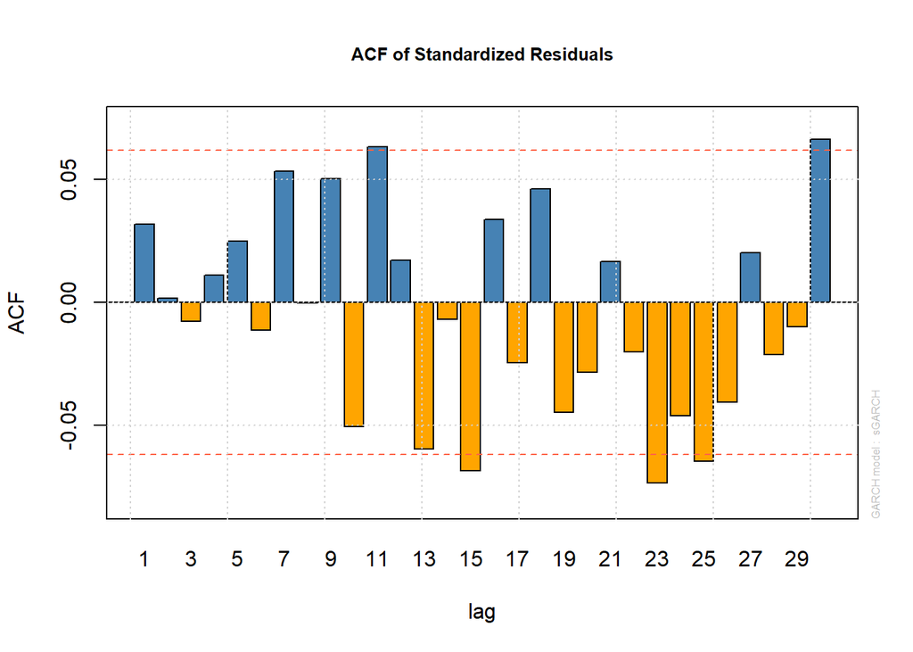

```r
plot(ARCH9,which = 10)
```

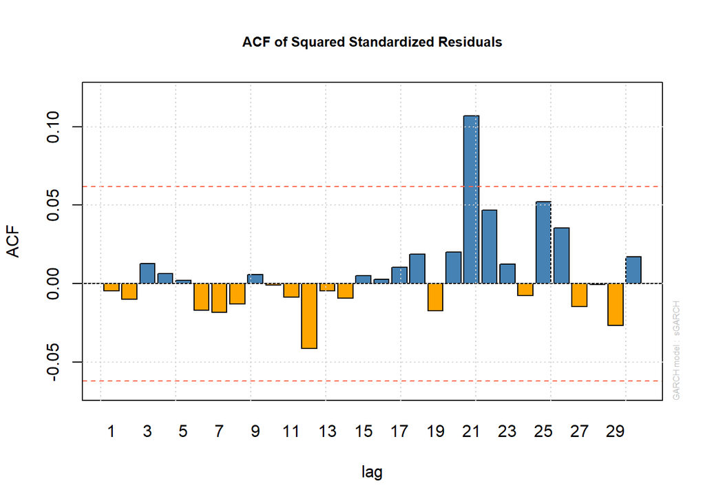

```r
plot(ARCH9,which = 11)
```

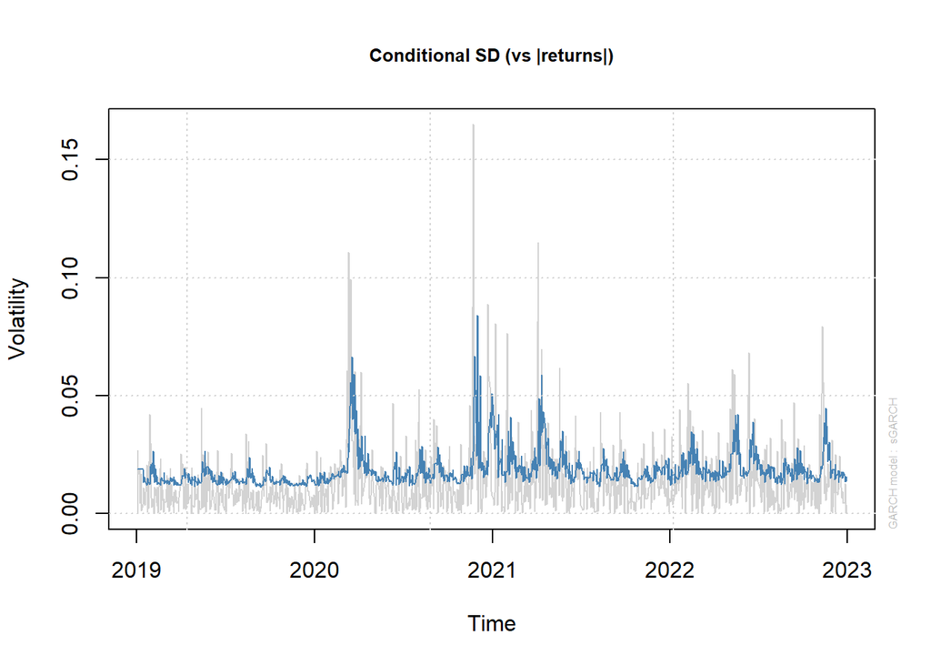

```r
plot(ARCH9,which = 3)
```

## 4.4 Aditional models

We will consider all ARCH models of order 1 to 9.

```r
arch <-c()
for (i in 1:9){
  spec <- ugarchspec(variance.model = list(garchOrder = c(i,0)), mean.model = list(armaOrder = c(0, 0)))
  arch_tmp <- ugarchfit(spec = spec, data = SNEUCX_train$LnReturns, solver = "hybrid")
  arch <- cbind(arch,arch_tmp)
}
```

# 5 GARCH models

## 5.1 GARCH(1,1)

```r
spec <- ugarchspec(variance.model = list(garchOrder = c(1,1)), mean.model = list(armaOrder = c(0, 0)))
GARCH11 <- ugarchfit(spec = spec, data = SNEUCX_train$LnReturns, solver = "hybrid")
print(GARCH11)
```

```
*---------------------------------*
*          GARCH Model Fit        *
*---------------------------------*

Conditional Variance Dynamics
-----------------------------------
GARCH Model : sGARCH(1,1)
Mean Model  : ARFIMA(0,0,0)
Distribution    : norm

Optimal Parameters
------------------------------------
        Estimate  Std. Error  t value Pr(>|t|)
mu      0.000498    0.000510  0.97628  0.32892
omega   0.000013    0.000001 10.44966  0.00000
alpha1  0.101832    0.010829  9.40356  0.00000
beta1   0.871633    0.013532 64.41362  0.00000

Robust Standard Errors:
        Estimate  Std. Error  t value Pr(>|t|)
mu      0.000498    0.000540  0.92215 0.356452
omega   0.000013    0.000003  4.14375 0.000034
alpha1  0.101832    0.016712  6.09355 0.000000
beta1   0.871633    0.017840 48.85728 0.000000

LogLikelihood : 2629.836

Information Criteria
------------------------------------

Akaike       -5.2152
Bayes        -5.1956
Shibata      -5.2152
Hannan-Quinn -5.2077

Weighted Ljung-Box Test on Standardized Residuals
------------------------------------
                        statistic p-value
Lag[1]                      1.568  0.2104
Lag[2*(p+q)+(p+q)-1][2]     1.663  0.3254
```

[output cut: 36 more lines]

```
Negative Sign Bias  0.4073 0.6838
Positive Sign Bias  1.0404 0.2984
Joint Effect        1.7632 0.6230


Adjusted Pearson Goodness-of-Fit Test:
------------------------------------
  group statistic p-value(g-1)
1    20     56.65   0.00001293
2    30     69.93   0.00003098
3    40     71.09   0.00127651
4    50     94.84   0.00009392


Elapsed time : 0.08636212
```

```r
jarque.bera.test(GARCH11@fit$residuals/sqrt(sigma(GARCH11)))
```

```
    Jarque Bera Test

data:  GARCH11@fit$residuals/sqrt(sigma(GARCH11))
X-squared = 3884.3, df = 2, p-value < 2.2e-16
```

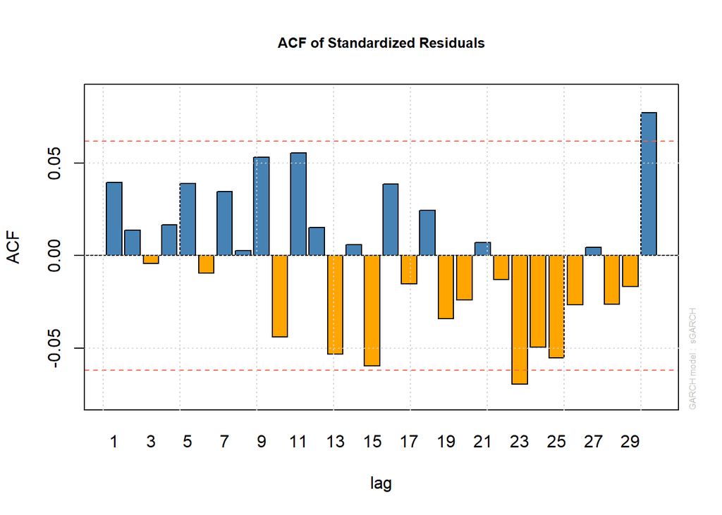

```r
plot(GARCH11,which = 10)
```

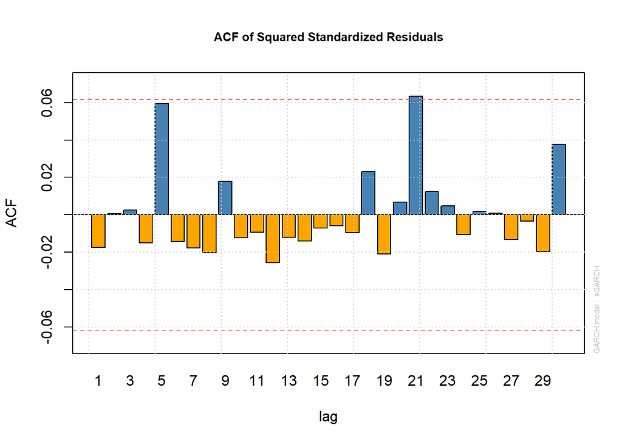

```r
plot(GARCH11,which = 11)
```

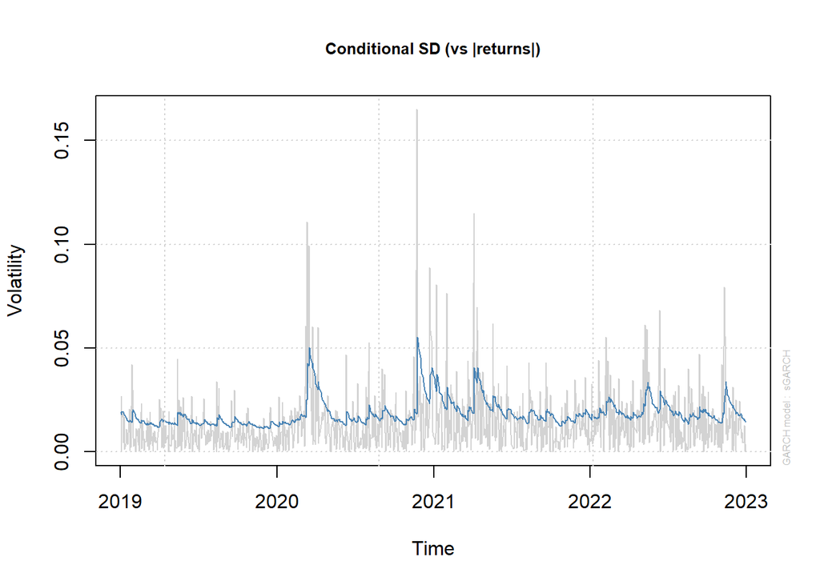

```r
plot(GARCH11,which = 3)
```

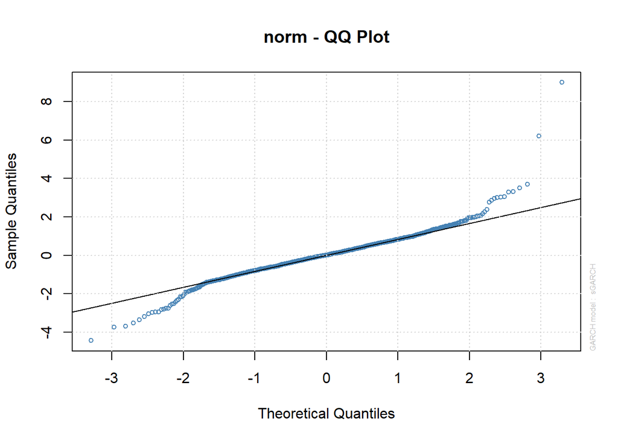

```r
plot(GARCH11, which = 9)
```

Looking at the first table with optimal parameters we can see that now all parameters are statistically significant except for mu in mean equation.

Ljung-box test on Standardized Residuals and the squared ones shows no autocorrelation within the residuals.

Based on Weighted ARCH LM test, ARCH effects are not present.

Nyblom stability test tells us that model parameters are jointly unstable, but looking at it individually, only omega is likely to change in time.

We reject the hypothesis that leverage effect is present.

ACF plot of standardized residuals and standardized squared residuals shows no significant serial autocorrelation up to 20th lag.

Based on Adjusted Pearson Goodness-of-Fit Test we can see that normal distribution does not fit the data, we will try with different distributions. By looking at qq plot we can see that marginal values lay significantly below/above solid line implying heavy tails.

As an addition we will fit GARCH-in-Mean model, to see if including risk premium will enhance our model.

```r
garch_models = c("sGARCH","eGARCH","apARCH")
distirbution = c("norm","std","sstd","ged","sged","snorm")
order_p = c(1,2)
order_q = c(1,2)

model_name <- c()
Akaike <-c()
Bayes <-c()
Shibata <-c()
HQ <-c()

for (i in 1:length(garch_models)){
  for (j in 1:length(distirbution)){
    for (k in 1:length(order_p)){
      for (l in 1:length(order_q)){

        spec <- ugarchspec(variance.model = list(garchOrder = c(order_p[k],order_q[l]),
          model = garch_models[i]),
          mean.model = list(armaOrder = c(0, 0)),
          distribution.model = distirbution[j])

        GARCH <- ugarchfit(spec = spec, data = SNEUCX_train$LnReturns, solver = "hybrid")
        model_name <- rbind(model_name,paste0(garch_models[i],"_",distirbution[j],"_",order_p[k],order_q[l]))
        if (is.null(GARCH)) {
          Akaike <- rbind(Akaike,NaN)
          Bayes <- rbind(Bayes,NaN)
          Shibata <- rbind(Shibata,NaN)
          HQ <- rbind(HQ,NaN)
        } else {
          Akaike <- rbind(Akaike,infocriteria(GARCH)[1])
          Bayes <- rbind(Bayes,infocriteria(GARCH)[2])
          Shibata <- rbind(Shibata,infocriteria(GARCH)[3])
          HQ <- rbind(HQ,infocriteria(GARCH)[4])
        }
      }
    }
  }
}

for (i in 1:length(garch_models)){
  for (j in 1:length(distirbution)){
    for (k in 1:length(order_p)){
      for (l in 1:length(order_q)){

        spec <- ugarchspec(variance.model = list(garchOrder = c(order_p[k],order_q[l]),
          model = garch_models[i]),
          mean.model = list(armaOrder = c(0, 0), archm = TRUE, archpow = 2),
          distribution.model = distirbution[j])

        GARCH <- ugarchfit(spec = spec, data = SNEUCX_train$LnReturns, solver = "hybrid")
        model_name <- rbind(model_name,paste0(garch_models[i],"_M","_",distirbution[j],"_",order_p[k],order_q[l]))
        if (is.null(GARCH)) {
          Akaike <- rbind(Akaike,NaN)
          Bayes <- rbind(Bayes,NaN)
          Shibata <- rbind(Shibata,NaN)
          HQ <- rbind(HQ,NaN)
        } else {
          Akaike <- rbind(Akaike,infocriteria(GARCH)[1])
          Bayes <- rbind(Bayes,infocriteria(GARCH)[2])
          Shibata <- rbind(Shibata,infocriteria(GARCH)[3])
          HQ <- rbind(HQ,infocriteria(GARCH)[4])
        }
      }
    }
  }
}
```

# 6 Summary of information criteria for models

```r
for (i in 1:length(arch)){
  model_name <- rbind(model_name,paste0("ARCH",i))
  Akaike <- rbind(Akaike,infocriteria(arch[[i]])[1])
  Bayes <- rbind(Bayes,infocriteria(arch[[i]])[2])
  Shibata <- rbind(Shibata,infocriteria(arch[[i]])[3])
  HQ <- rbind(HQ,infocriteria(arch[[i]])[4])
}

scores <- cbind(model_name, Akaike, Bayes, Shibata, HQ)
colnames(scores) <- c("Model","Akaike","Bayes","Shibata","Hannan-Quinn")

scores %>%
  datatable(rownames = FALSE, class = 'cell-border stripe') %>%
  formatRound(columns = c("Akaike","Bayes","Shibata","Hannan-Quinn"), digits = 4)
```

| Model | Akaike | Bayes | Shibata | Hannan-Quinn |
| --- | --- | --- | --- | --- |
| sGARCH_norm_11 | -5.21516674251042 | -5.19564447481342 | -5.21519813302817 | -5.20774943130561 |
| sGARCH_norm_12 | -5.21675069795468 | -5.19234786333343 | -5.21679968121852 | -5.20747905894867 |
| sGARCH_norm_21 | -5.21777337191589 | -5.19337053729464 | -5.21782235517973 | -5.20850173290988 |
| sGARCH_norm_22 | -5.215874492245 | -5.1865910906995 | -5.21594493565345 | -5.20474852543779 |
| sGARCH_std_11 | -5.38472415726797 | -5.36032132264672 | -5.38477314053181 | -5.37545251826196 |
| sGARCH_std_12 | -5.38271714783642 | -5.35343374629093 | -5.38278759124487 | -5.37159118102921 |
| sGARCH_std_21 | -5.38328297276193 | -5.35399957121644 | -5.38335341617038 | -5.37215700595472 |
| sGARCH_std_22 | -5.38297724171987 | -5.34881327325013 | -5.38307299750515 | -5.36999694711146 |
| sGARCH_sstd_11 | -5.3827384281404 | -5.35345502659491 | -5.38280887154885 | -5.37161246133319 |
| sGARCH_sstd_12 | -5.3807309469107 | -5.34656697844096 | -5.38082670269598 | -5.36775065230229 |

[output cut: 143 more lines]

We can see that best performing models in terms of BIC scores are with t-student distribution.

We will choose models based on Bayes information criterion, two models with the lowest scores are:

- standard GARCH with t-student distribution of order (1,1)
- exponential GARCH with t-student distribution of order (1,1).

If we consider Akaike and Shibata scores, the second best model is

- asymmetric power ARCH model with t-student distribution or order (1,1)

We will use this models for VAR modeling in later steps. Additionally we will include

- standard GARCH-in-Mean model with t-student distribution of order (1,1)

for research purposes.

## 6.1 Investigation of models

### 6.1.1 GARCH-t(1,1)

```r
spec <- ugarchspec(variance.model = list(garchOrder = c(1,1),
        model = "sGARCH"),
        mean.model = list(armaOrder = c(0, 0)),
        distribution.model = "std")

sGARCH_std_11 <- ugarchfit(spec = spec, data = SNEUCX_train$LnReturns, solver = "hybrid")

print(sGARCH_std_11)
```

```
*---------------------------------*
*          GARCH Model Fit        *
*---------------------------------*

Conditional Variance Dynamics
-----------------------------------
GARCH Model : sGARCH(1,1)
Mean Model  : ARFIMA(0,0,0)
Distribution    : std

Optimal Parameters
------------------------------------
        Estimate  Std. Error  t value Pr(>|t|)
mu      0.000815    0.000442   1.8421 0.065458
omega   0.000012    0.000001   8.8544 0.000000
alpha1  0.076243    0.002886  26.4223 0.000000
beta1   0.890562    0.015231  58.4706 0.000000
shape   4.260373    0.494034   8.6236 0.000000

Robust Standard Errors:
        Estimate  Std. Error  t value Pr(>|t|)
mu      0.000815    0.000450   1.8122 0.069948
omega   0.000012    0.000002   6.3896 0.000000
alpha1  0.076243    0.009169   8.3155 0.000000
beta1   0.890562    0.013177  67.5829 0.000000
shape   4.260373    0.523620   8.1364 0.000000

LogLikelihood : 2716.209

Information Criteria
------------------------------------

Akaike       -5.3847
Bayes        -5.3603
Shibata      -5.3848
Hannan-Quinn -5.3755

Weighted Ljung-Box Test on Standardized Residuals
------------------------------------
                        statistic p-value
```

[output cut: 39 more lines]

```
Negative Sign Bias  0.7237 0.4694
Positive Sign Bias  0.9682 0.3332
Joint Effect        2.1469 0.5425


Adjusted Pearson Goodness-of-Fit Test:
------------------------------------
  group statistic p-value(g-1)
1    20     11.17       0.9179
2    30     23.22       0.7665
3    40     27.24       0.9219
4    50     37.04       0.8951


Elapsed time : 0.171298
```

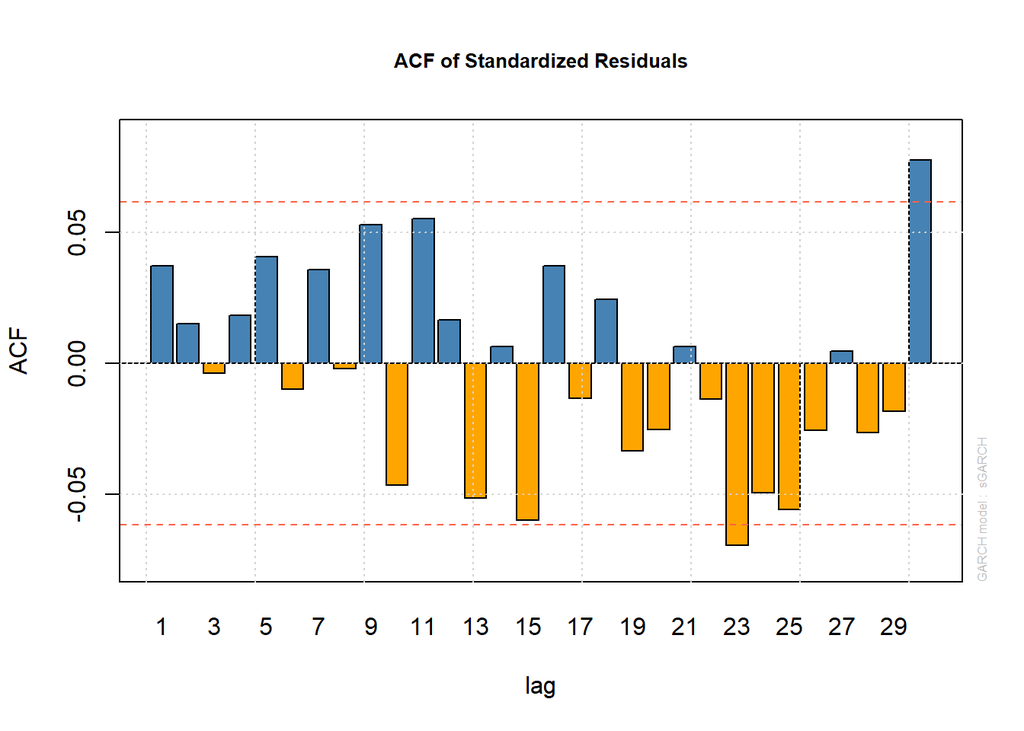

```r
plot(sGARCH_std_11,which = 10)
```

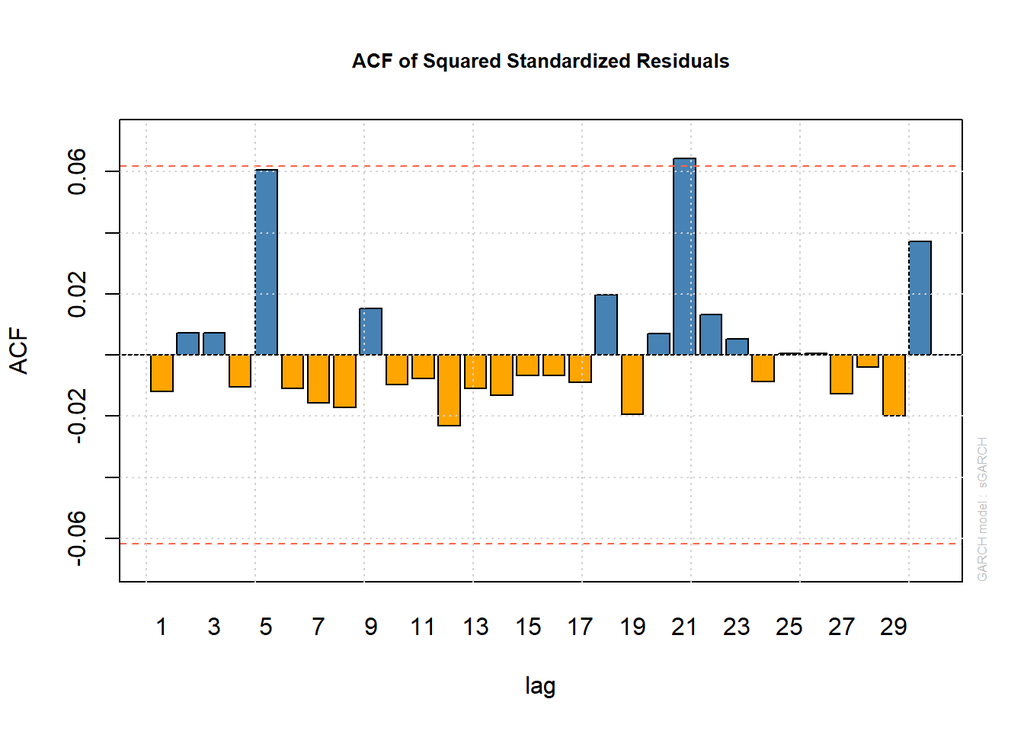

```r
plot(sGARCH_std_11,which = 11)
```

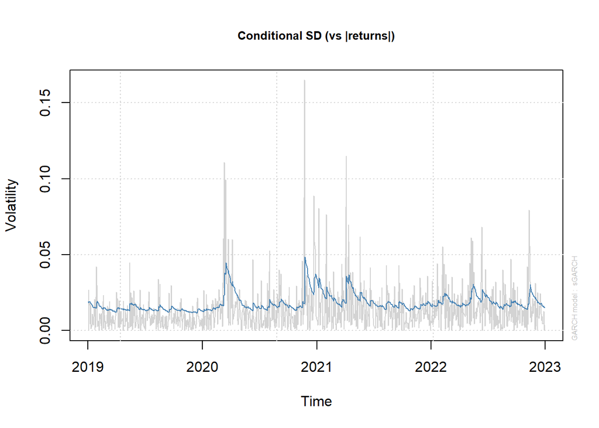

```r
plot(sGARCH_std_11,which = 3)
```

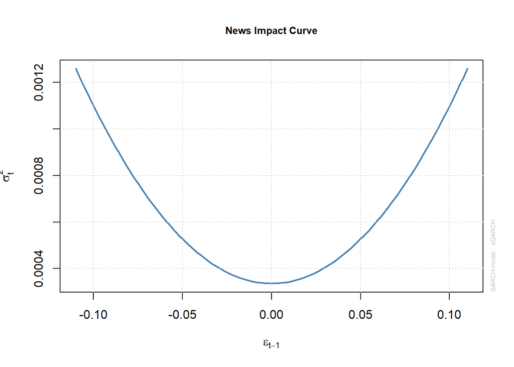

```r
plot(sGARCH_std_11, which = 12)
```

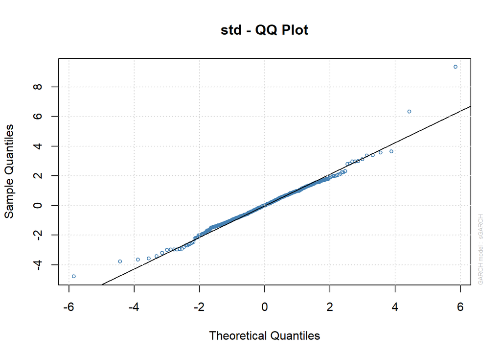

```r
plot(sGARCH_std_11, which = 9)
```

Optimal parameters:

LB test:

- no serial autocorrelation in standardized residuals - correct mean equation
- no serial autocorrelation in standardized squared residuals - correct variance equation

ARCH LM test:

- no ARCH effects

Nyblom stability test:

- jointly not stable
- individually only mu is stable

Sign bias test:

- there is no leverage effect

Goodness-of-fit:

- t-Student distribution fits the data distribution

Based on ACF of standardized residuals none of lags until 15 is autocorrelated, based on ACF on squared standardized residuals variance model is correct - no significant autocorrelation until 21 lag. News impact curve shows us that the impact of innovation on volatility is symmetric. QQ plot seems to be correct - t distribution matches data distribution.

### 6.1.2 EGARCH-t(1,1)

```r
spec <- ugarchspec(variance.model = list(garchOrder = c(1,1),
        model = "eGARCH"),
        mean.model = list(armaOrder = c(0, 0)),
        distribution.model = "std")

eGARCH_std_11 <- ugarchfit(spec = spec, data = SNEUCX_train$LnReturns, solver = "hybrid")

print(eGARCH_std_11)
```

```
*---------------------------------*
*          GARCH Model Fit        *
*---------------------------------*

Conditional Variance Dynamics
-----------------------------------
GARCH Model : eGARCH(1,1)
Mean Model  : ARFIMA(0,0,0)
Distribution    : std

Optimal Parameters
------------------------------------
        Estimate  Std. Error  t value Pr(>|t|)
mu      0.000720    0.000300   2.4033 0.016247
omega  -0.293201    0.035902  -8.1667 0.000000
alpha1 -0.029277    0.022337  -1.3107 0.189956
beta1   0.963863    0.004347 221.7147 0.000000
gamma1  0.176305    0.035648   4.9458 0.000001
shape   4.265269    0.559792   7.6194 0.000000

Robust Standard Errors:
        Estimate  Std. Error  t value Pr(>|t|)
mu      0.000720    0.000211   3.4173 0.000633
omega  -0.293201    0.019366 -15.1396 0.000000
alpha1 -0.029277    0.021958  -1.3333 0.182425
beta1   0.963863    0.002075 464.5048 0.000000
gamma1  0.176305    0.040210   4.3846 0.000012
shape   4.265269    0.590602   7.2219 0.000000

LogLikelihood : 2717.687

Information Criteria
------------------------------------

Akaike       -5.3857
Bayes        -5.3564
Shibata      -5.3857
Hannan-Quinn -5.3745

Weighted Ljung-Box Test on Standardized Residuals
```

[output cut: 42 more lines]

```
Negative Sign Bias  0.6063 0.5445
Positive Sign Bias  0.7889 0.4303
Joint Effect        2.0869 0.5546


Adjusted Pearson Goodness-of-Fit Test:
------------------------------------
  group statistic p-value(g-1)
1    20     13.52       0.8111
2    30     21.43       0.8430
3    40     35.82       0.6157
4    50     38.53       0.8589


Elapsed time : 0.224009
```

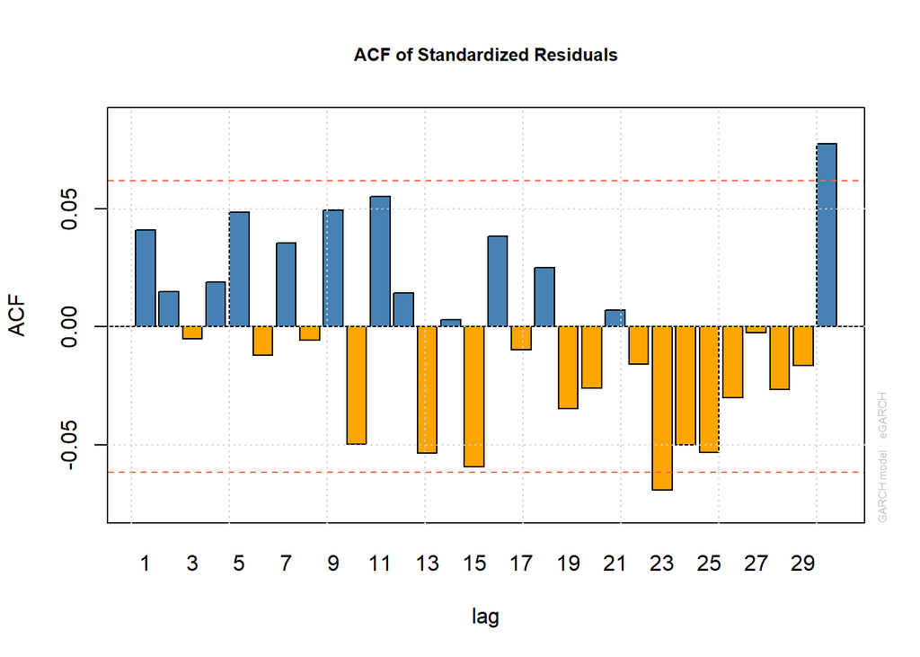

```r
plot(eGARCH_std_11,which = 10)
```

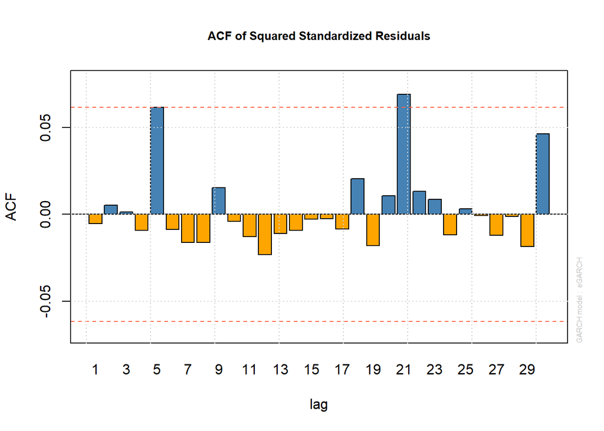

```r
plot(eGARCH_std_11,which = 11)
```

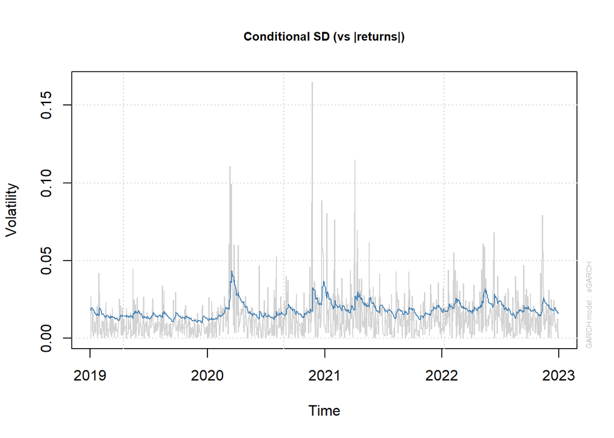

```r
plot(eGARCH_std_11,which = 3)
```

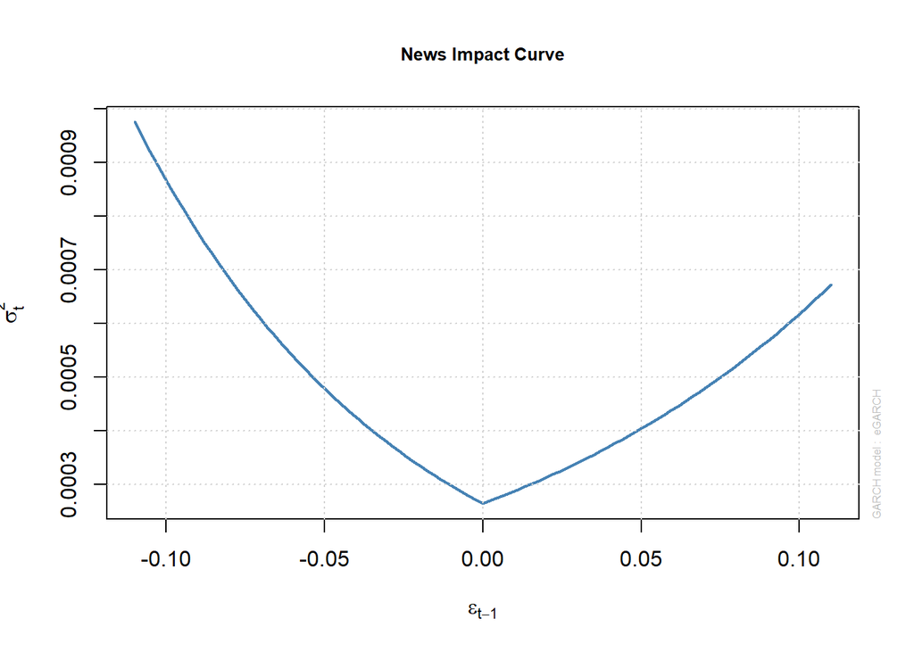

```r
plot(eGARCH_std_11, which = 12)
```

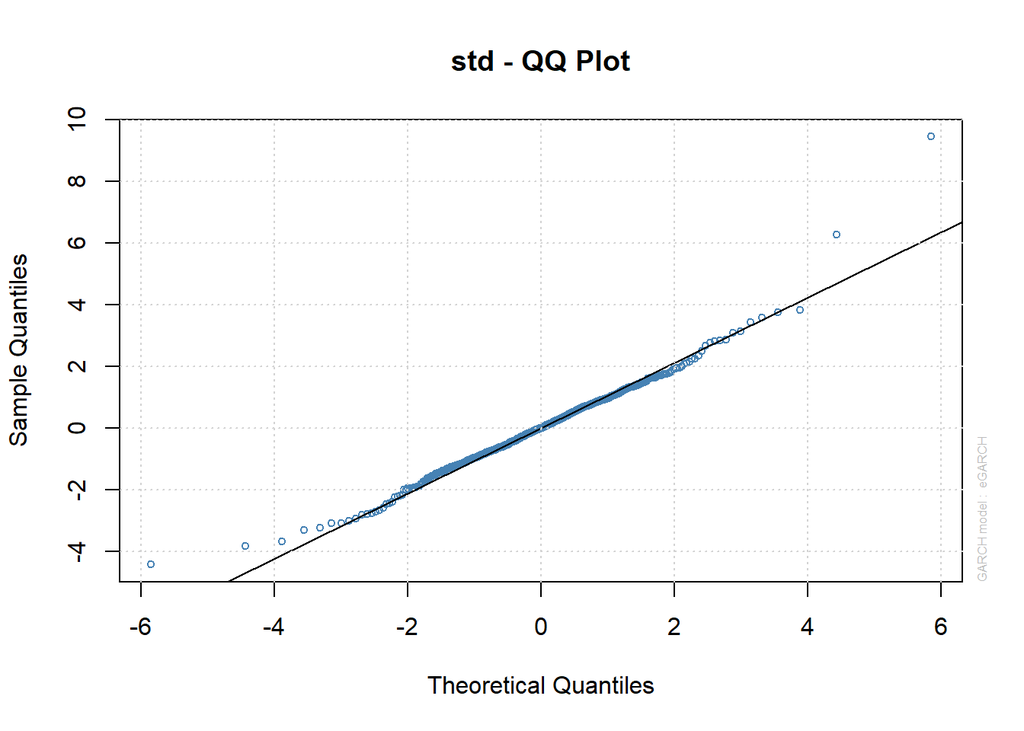

```r
plot(eGARCH_std_11, which = 9)
```

Optimal parameters:

LB test:

- no serial autocorrelation in standardized residuals - correct mean equation
- no serial autocorrelation in standardized squared residuals - correct variance equation

ARCH LM test:

- no ARCH effects

Nyblom stability test:

- model jointly is stable
- individually only omega and beta1 are not stable

Sign bias test:

- there is no leverage effect

Goodness-of-fit:

- t-Student distribution fits the data distribution

Based on ACF of standardized residuals none of lags until 23 is autocorrelated, based on ACF on squared standardized residuals variance model is correct - no significant autocorrelation until 21 lag, 5th lag is on the verge of the significance. News impact curve shows us that the impact of innovation on volatility is not symmetric - impact of negative innovation on volatility is higher than for positive innovations. QQ plot seems to be correct - t distribution matches data distribution.

### 6.1.3 apARCH-t(1,1)

```r
spec <- ugarchspec(variance.model = list(garchOrder = c(1,1),
        model = "apARCH"),
        mean.model = list(armaOrder = c(0, 0)),
        distribution.model = "std")

apARCH_std_11 <- ugarchfit(spec = spec, data = SNEUCX_train$LnReturns, solver = "hybrid")

print(apARCH_std_11)
```

```
*---------------------------------*
*          GARCH Model Fit        *
*---------------------------------*

Conditional Variance Dynamics
-----------------------------------
GARCH Model : apARCH(1,1)
Mean Model  : ARFIMA(0,0,0)
Distribution    : std

Optimal Parameters
------------------------------------
        Estimate  Std. Error  t value Pr(>|t|)
mu      0.000705    0.000446   1.5807 0.113954
omega   0.000027    0.000052   0.5258 0.599025
alpha1  0.082758    0.025266   3.2754 0.001055
beta1   0.885709    0.031032  28.5417 0.000000
gamma1  0.200042    0.105513   1.8959 0.057975
delta   1.817262    0.491358   3.6984 0.000217
shape   4.298540    0.560978   7.6626 0.000000

Robust Standard Errors:
        Estimate  Std. Error  t value Pr(>|t|)
mu      0.000705    0.000462  1.52598 0.127016
omega   0.000027    0.000044  0.61943 0.535632
alpha1  0.082758    0.022414  3.69227 0.000222
beta1   0.885709    0.032874 26.94221 0.000000
gamma1  0.200042    0.100863  1.98331 0.047333
delta   1.817262    0.452535  4.01574 0.000059
shape   4.298540    0.598465  7.18261 0.000000

LogLikelihood : 2718.443

Information Criteria
------------------------------------

Akaike       -5.3852
Bayes        -5.3510
Shibata      -5.3853
Hannan-Quinn -5.3722
```

[output cut: 45 more lines]

```
Negative Sign Bias  0.3874 0.6985
Positive Sign Bias  0.7695 0.4418
Joint Effect        1.7210 0.6323


Adjusted Pearson Goodness-of-Fit Test:
------------------------------------
  group statistic p-value(g-1)
1    20     11.21       0.9165
2    30     25.01       0.6779
3    40     30.50       0.8330
4    50     41.11       0.7810


Elapsed time : 1.976695
```

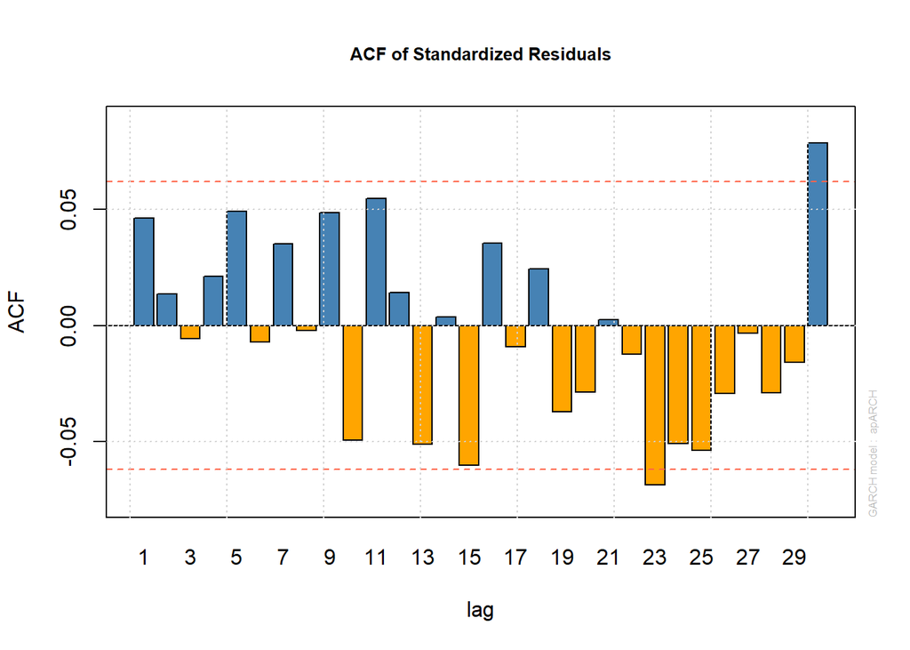

```r
plot(apARCH_std_11,which = 10)
```

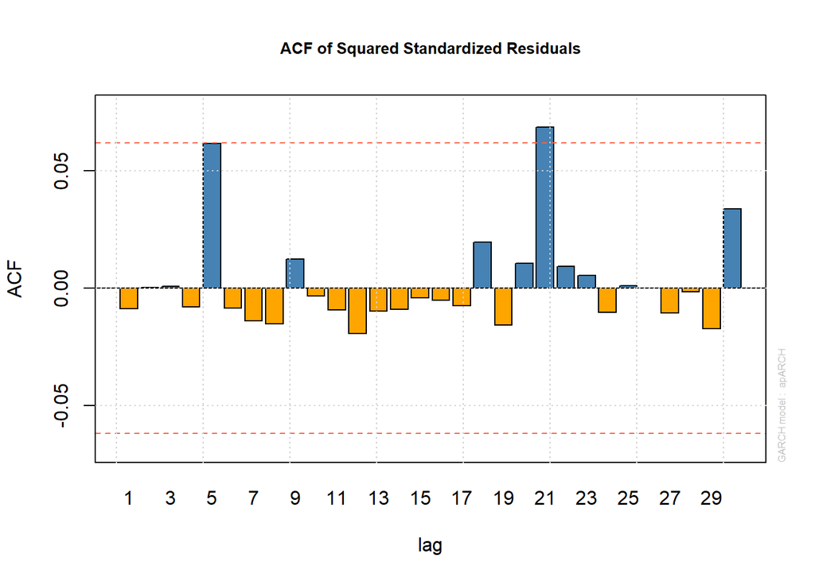

```r
plot(apARCH_std_11,which = 11)
```

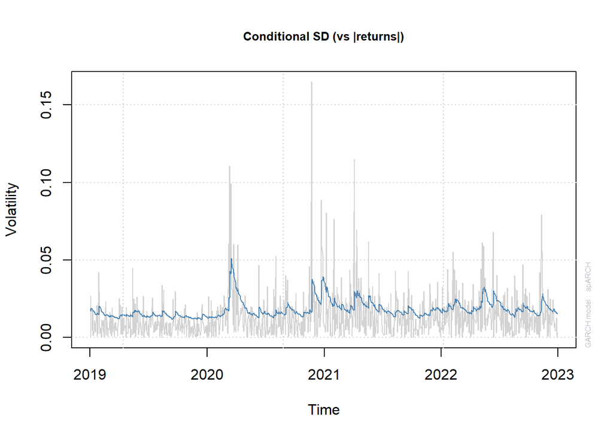

```r
plot(apARCH_std_11,which = 3)
```

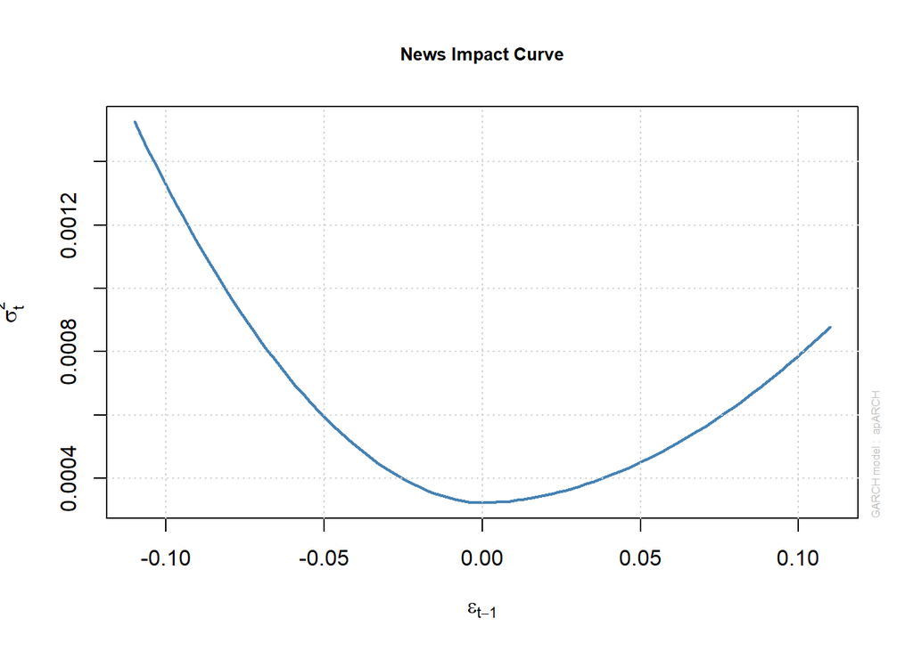

```r
plot(apARCH_std_11, which = 12)
```

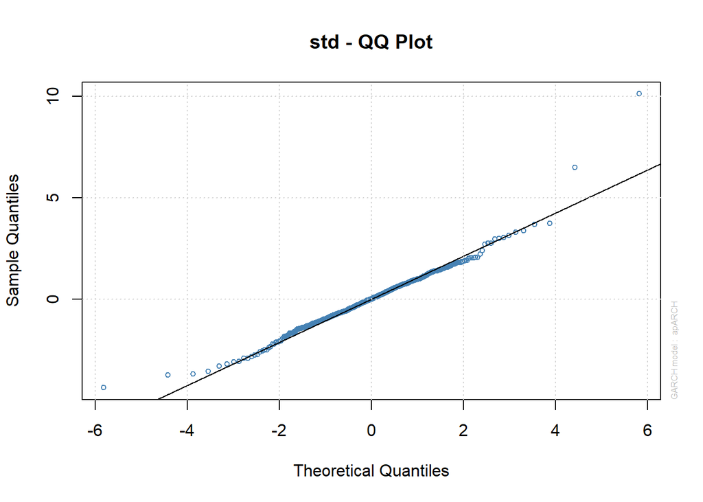

```r
plot(apARCH_std_11, which = 9)
```

Optimal parameters:

- all the parameters are significant except for omega and mu (intercept of variance equation and mean equation). Leverage parameter, gamma is significant with positive estimate meaning that negative innovation has higher effect than positive innovations.

LB test:

- no serial autocorrelation in standardized residuals - correct mean equation
- no serial autocorrelation in standardized squared residuals - correct variance equation

ARCH LM test:

- no ARCH effects

Nyblom stability test:

- model jointly is stable
- individually omega, alpha1, delta, shape and beta1 are not stable

Sign bias test:

- there is no leverage effect

Goodness-of-fit:

- t-Student distribution fits the data distribution

Based on ACF of standardized residuals none of lags until 15 is autocorrelated, based on ACF on squared standardized residuals variance model is correct - no significant autocorrelation until 21 lag, 5th lag is on the verge of the significance. News impact curve shows us that the impact of innovation on volatility is not symmetric - impact of negative innovation on volatility is higher than for positive impacts. In comparison to EGARCH we can see that New Impact Curve is more convex. QQ plot seems to be correct -t-distribution matches data distribution.

### 6.1.5 GARCH-in-Mean-t(1,1)

```r
spec <- ugarchspec(variance.model = list(garchOrder = c(1,1),
        model = "sGARCH"),
        mean.model = list(armaOrder = c(0, 0), archm = TRUE, archpow = 2),
        distribution.model = "std")

sGARCH_M_std_11 <- ugarchfit(spec = spec, data = SNEUCX_train$LnReturns, solver = "hybrid")

print(sGARCH_M_std_11)
```

```
*---------------------------------*
*          GARCH Model Fit        *
*---------------------------------*

Conditional Variance Dynamics
-----------------------------------
GARCH Model : sGARCH(1,1)
Mean Model  : ARFIMA(0,0,0)
Distribution    : std

Optimal Parameters
------------------------------------
        Estimate  Std. Error  t value Pr(>|t|)
mu      0.000620    0.000888  0.69772  0.48535
archm   0.711097    2.809848  0.25307  0.80021
omega   0.000012    0.000001  8.85695  0.00000
alpha1  0.076287    0.003011 25.34001  0.00000
beta1   0.890530    0.015232 58.46606  0.00000
shape   4.264569    0.495277  8.61047  0.00000

Robust Standard Errors:
        Estimate  Std. Error  t value Pr(>|t|)
mu      0.000620    0.000842  0.73644  0.46147
archm   0.711097    2.257141  0.31504  0.75273
omega   0.000012    0.000002  6.41718  0.00000
alpha1  0.076287    0.009059  8.42119  0.00000
beta1   0.890530    0.013104 67.95922  0.00000
shape   4.264569    0.523184  8.15119  0.00000

LogLikelihood : 2716.241

Information Criteria
------------------------------------

Akaike       -5.3828
Bayes        -5.3535
Shibata      -5.3829
Hannan-Quinn -5.3717

Weighted Ljung-Box Test on Standardized Residuals
```

[output cut: 42 more lines]

```
Negative Sign Bias  0.6926 0.4887
Positive Sign Bias  0.9716 0.3315
Joint Effect        2.1107 0.5497


Adjusted Pearson Goodness-of-Fit Test:
------------------------------------
  group statistic p-value(g-1)
1    20     14.39       0.7605
2    30     28.94       0.4683
3    40     30.66       0.8277
4    50     39.62       0.8281


Elapsed time : 0.3368549
```

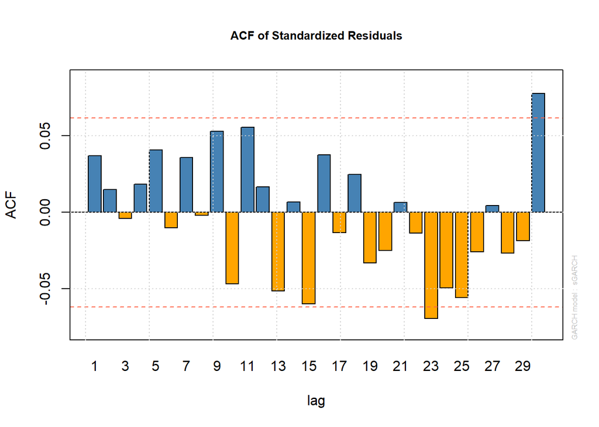

```r
plot(sGARCH_M_std_11,which = 10)
```

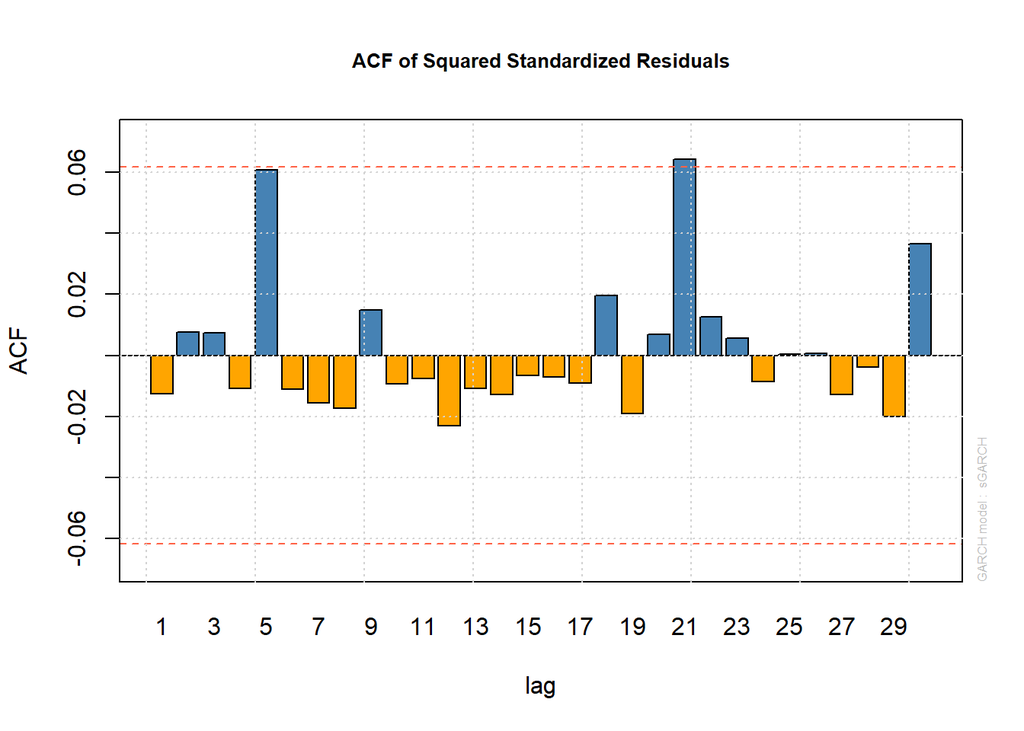

```r
plot(sGARCH_M_std_11,which = 11)
```

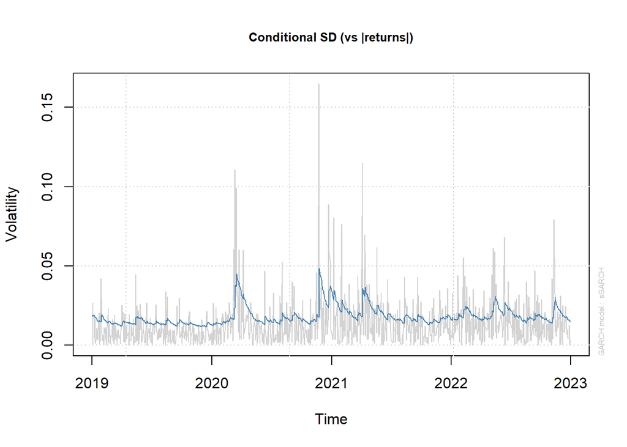

```r
plot(sGARCH_M_std_11,which = 3)
```

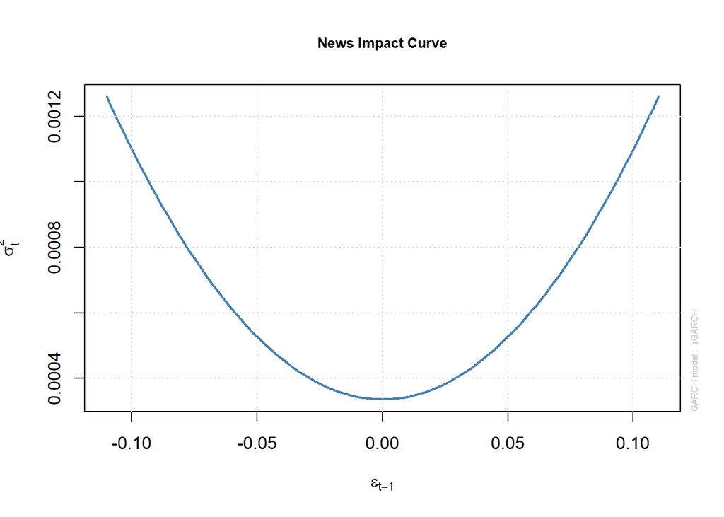

```r
plot(sGARCH_M_std_11, which = 12)
```

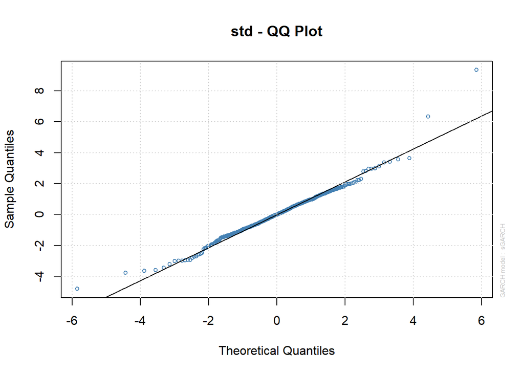

```r
plot(sGARCH_M_std_11, which = 9)
```

Optimal parameters:

- all the parameters are significant except for mu and archm. Positive archm parameter indicates that there is risk premium but this parameter is statistically insignificant.

LB test:

- no serial autocorrelation in standardized residuals - correct mean equation
- no serial autocorrelation in standardized squared residuals - correct variance equation

ARCH LM test:

- no ARCH effects

Nyblom stability test:

Sign bias test:

- there is no leverage effect

Goodness-of-fit:

- t-Student distribution fits the data distribution

Based on ACF of standardized residuals none of lags until 23 is autocorrelated, based on ACF on squared standardized residuals variance model is correct - no significant autocorrelation until 21 lag. News impact curve shows us that the impact of innovation on volatility is symmetric. QQ plot seems to be correct t-distribution matches data distribution.

# 7 Save models

```r
saveRDS(sGARCH_std_11,"models/sGARCH_std_11.rds")
saveRDS(eGARCH_std_11,"models/eGARCH_std_11.rds")
saveRDS(apARCH_std_11,"models/apARCH_std_11.rds")
saveRDS(sGARCH_M_std_11,"models/sGARCH_M_std_11.rds")
```